# Sleep Quality Analysis

- Show All Code
- Hide All Code
- View Source

Comprehensive study of factors affecting sleep quality using supervised learning models (GLM, Random Forest, GBM)

Author

Patricia Fernández Sanz

El propósito de este trabajo es aplicar técnicas de modelización predictiva para resolver un problema realista, desde la preparación de datos hasta la evaluación de modelos, con el fin de comparar su rendimiento y justificar la elección final.

# Elección de la Base de Datos

En primer lugar, se debía elegir una base de datos que tuviese una variable objetivo de tipo continuo, discreto, binario, nominal u ordinal (en nuestro caso ordinal, pero se explicará más en detalle a continuación)

# Carga de Librerías y Datos

Antes de proceder con cualquier proceso de depuración o análisis, se cargan las distintas librerías que se necesitarán a lo largo del proyecto y los datos.

```r
library(MASS)
library(stargazer)
library(caret)
library(car)
library(vcd)
library(purrr)
library(dplyr)
library(nnet)
library(lmtest)
library(rpart)
library(rpart.plot)
library(pROC)
library(rattle)
library(vcd)
library(partykit)
library(rpartScore)
library(randomForest)
library(OOBCurve)
library(furrr)
library(iml)
library(glmnet)
library(lubridate)
library(adabag)
library(gbm)
# Para paralelizar
library(doParallel)
cluster <- makeCluster(detectCores() - 1)
registerDoParallel(cluster)
```

Una vez están cargadas todas las librerías, se cargan los datos.

```r
datos<-read.csv("stress_detection_data.csv")
```

# Descripción de la Base

La siguiente base de datos consiste en un estudio de individuos reales donde se tienen en cuenta sus hábitos de vida, salud e indicadores de estrés.

Cuenta con las siguientes 22 variables:

Para el estudio se va a utilizar como variable objetivo **Sleep_Quality** en función de los distintos factores que muestra el individuo. Además, como son valores reales, podemos extrapolar los resultados a la población.

# Depuración de Datos

Antes de comenzar a trabajar en los distintos modelos, se deben revisar las distintas variables y valores de las mismas que toma la base de datos, pasar a factor aquellas que lo necesiten y reagrupar aquellas variables que tengan muy pocas observaciones por categoría.

## Codificación y transformación

Se procede, con la ayuda de la función str(), a ver cómo están declaradas las variables y, en caso de que sea necesario, recodificarlas.

```r
str(datos)
```

```
'data.frame':   773 obs. of  22 variables:
 $ Age                : int  30 35 40 35 29 45 32 37 50 40 ...
 $ Gender             : chr  "Male" "Female" "Male" "Male" ...
 $ Occupation         : chr  "Software Engineer" "Marketing Manager" "Data Scientist" "Software Engineer" ...
 $ Marital_Status     : chr  "Single" "Married" "Divorced" "Single" ...
 $ Sleep_Duration     : num  7 6 7 7 8 6 7 7.5 5.5 6 ...
 $ Sleep_Quality      : num  4 3 4 4 5 3 4 4 2 3 ...
 $ Wake_Up_Time       : chr  "7:00 AM" "6:00 AM" "7:00 AM" "7:00 AM" ...
 $ Bed_Time           : chr  "10:00 PM" "11:00 PM" "10:00 PM" "10:00 PM" ...
 $ Physical_Activity  : num  2 1 2 2 3 2 1 2.5 2 3 ...
 $ Screen_Time        : num  4 3 4 4 2 4 6 3.5 8 4.5 ...
 $ Caffeine_Intake    : int  1 0 1 1 1 2 3 2 3 2 ...
 $ Alcohol_Intake     : int  0 1 0 0 0 1 0 0 2 0 ...
 $ Smoking_Habit      : chr  "No" "No" "No" "No" ...
 $ Work_Hours         : int  8 9 8 8 7 10 9 8 12 9 ...
 $ Travel_Time        : num  1 2 1 1 1 2 0.5 1.5 2 1 ...
 $ Social_Interactions: int  5 3 5 5 4 3 2 5 2 4 ...
 $ Meditation_Practice: chr  "Yes" "No" "Yes" "Yes" ...
 $ Exercise_Type      : chr  "Cardio" "Yoga" "Strength Training" "Cardio" ...
 $ Blood_Pressure     : int  120 110 130 120 110 130 120 140 150 125 ...
 $ Cholesterol_Level  : int  180 160 200 180 180 220 190 210 240 200 ...
 $ Blood_Sugar_Level  : int  90 80 100 90 90 110 85 100 130 105 ...
 $ Stress_Detection   : chr  "Low" "Medium" "High" "Low" ...
```

De base vemos como se cuenta con 22 variables (21 predictoras y la variable objetivo Sleep Quality).

En primer lugar se deberán pasar a factor las variables Gender, Occupation, Marital_Status, Smoking_Habit, Meditation_Practice, Exercise_Type y Stress_Detection. En el caso de Sleep_Quality, también se pasará a factores pero primero debemos ver y reagrupar los valores que toma (puesto que hay valores con decimales).

También se deberán recodificar las variables Wake_Up_Time y Bed_Time para que tomen valores de 0 a 23 respectivamente para tratar las horas como una variable numérica.

A tener en cuenta que en esta segunda variable, en ocasiones toma valores 1:00 AM, que parece “temprano” pero en realidad es tarde ya que es el día siguiente. Para arreglarlo, se va a convertir esa variable a un horario continuo donde la noche se va a extender más allá de las 24h para poder tener en cuenta estos valores.

### Paso a Factor

```r
datos$Gender <- factor(
  ifelse(datos$Gender == "Male", 1, 2),
  levels = c(1, 2),
  labels = c("Male", "Female"))

datos$Occupation <- as.factor(datos$Occupation)

datos$Marital_Status <- factor(
  ifelse(datos$Marital_Status == "Single", 0,
         ifelse(datos$Marital_Status == "Married", 1, 2)),
  levels = c(0, 1, 2),
  labels = c("Single", "Married", "Divorced")
)

#datos$Sleep_Quality <- as.factor(datos$Sleep_Quality)

datos$Wake_Up_Time <- hour(parse_date_time(datos$Wake_Up_Time, orders = c("h:M p", "H:M")))
datos$Bed_Time <- hour(parse_date_time(datos$Bed_Time, orders = c("h:M p", "H:M")))
# Ajustamos para que horas tempranas (0-5 am) sean consideradas como tarde
datos$Bed_Time <- ifelse(datos$Bed_Time < 6, datos$Bed_Time + 24, datos$Bed_Time)

datos$Smoking_Habit <- factor(
  ifelse(datos$Smoking_Habit == "No", 1, 2),
  levels = c(1, 2),
  labels = c("No", "Yes"))

datos$Meditation_Practice <- factor(
  ifelse(datos$Meditation_Practice == "No", 1, 2),
  levels = c(1, 2),
  labels = c("No", "Yes"))

datos$Exercise_Type <- as.factor(datos$Exercise_Type)

datos$Stress_Detection <- factor(
  ifelse(datos$Stress_Detection == "Low", 1,
         ifelse(datos$Stress_Detection == "Medium", 2, 3)),
  levels = c(1, 2, 3),
  labels = c("Low", "Medium", "High")
)
```

Se confirma que todos los cambios se han hecho correctamente

```r
str(datos)
```

```
'data.frame':   773 obs. of  22 variables:
 $ Age                : int  30 35 40 35 29 45 32 37 50 40 ...
 $ Gender             : Factor w/ 2 levels "Male","Female": 1 2 1 1 2 1 2 1 1 2 ...
 $ Occupation         : Factor w/ 169 levels "Account Manager",..: 151 94 39 151 158 46 70 23 19 103 ...
 $ Marital_Status     : Factor w/ 3 levels "Single","Married",..: 1 2 3 1 1 2 1 2 2 3 ...
 $ Sleep_Duration     : num  7 6 7 7 8 6 7 7.5 5.5 6 ...
 $ Sleep_Quality      : num  4 3 4 4 5 3 4 4 2 3 ...
 $ Wake_Up_Time       : int  7 6 7 7 6 5 7 6 5 6 ...
 $ Bed_Time           : num  22 23 22 22 22 23 24 22 24 23 ...
 $ Physical_Activity  : num  2 1 2 2 3 2 1 2.5 2 3 ...
 $ Screen_Time        : num  4 3 4 4 2 4 6 3.5 8 4.5 ...
 $ Caffeine_Intake    : int  1 0 1 1 1 2 3 2 3 2 ...
 $ Alcohol_Intake     : int  0 1 0 0 0 1 0 0 2 0 ...
 $ Smoking_Habit      : Factor w/ 2 levels "No","Yes": 1 1 1 1 1 2 1 1 2 1 ...
 $ Work_Hours         : int  8 9 8 8 7 10 9 8 12 9 ...
 $ Travel_Time        : num  1 2 1 1 1 2 0.5 1.5 2 1 ...
 $ Social_Interactions: int  5 3 5 5 4 3 2 5 2 4 ...
 $ Meditation_Practice: Factor w/ 2 levels "No","Yes": 2 1 2 2 2 1 1 2 1 2 ...
 $ Exercise_Type      : Factor w/ 7 levels "Aerobics","Cardio",..: 2 7 5 2 7 2 1 5 6 4 ...
 $ Blood_Pressure     : int  120 110 130 120 110 130 120 140 150 125 ...
 $ Cholesterol_Level  : int  180 160 200 180 180 220 190 210 240 200 ...
 $ Blood_Sugar_Level  : int  90 80 100 90 90 110 85 100 130 105 ...
 $ Stress_Detection   : Factor w/ 3 levels "Low","Medium",..: 1 2 3 1 1 3 2 2 3 2 ...
```

Y se revisan los valores que toma la variable Bed_Time

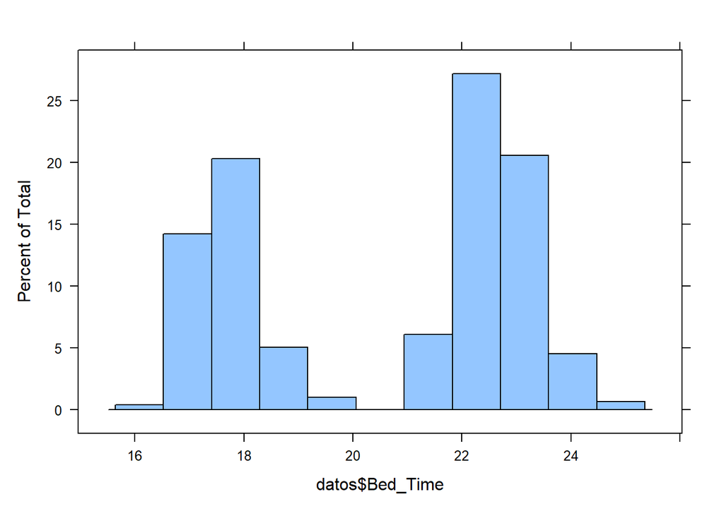

```r
histogram(datos$Bed_Time)
```

Al haber realizado la modificación en como se tratan las horas, se observa que efectivamente hay individuos que se van a la cama pasado media noche.

## Reagrupación de Categorías

### Sleep_Quality

Primero y más importante, se deben comprobar los valores que toma la variable objetivo, ya que si desde el comienzo se encuentra muy desbalanceada, podemos tener muchos problemas de cara a futuro en la predicción.

```r
table(datos$Sleep_Quality)/nrow(datos)
```

```
          2         2.5         2.9           3         3.1         3.2
0.003880983 0.002587322 0.002587322 0.122897801 0.012936611 0.028460543
        3.3         3.4         3.5         3.6         3.7         3.8
0.016817594 0.021992238 0.029754204 0.028460543 0.073738680 0.102199224
        3.9           4         4.1         4.2         4.3         4.5
0.073738680 0.266494179 0.051746442 0.037516171 0.014230272 0.011642950
          5
0.098318241
```

Observamos que toma muchos valores intermedios. Esto se debe a que es un indicador personal de cada individuo en función de lo que el siente que ha experimentado entre un rango de 1 y 5. Como hay muchos valores que cuentan con un porcentaje de individuos muy pequeño, se van a hacer nuevos rangos.

El primero tomará todos los valores por debajo o igual a 3.4 (Pobre), el segundo los valores desde 3.5 hasta 3.8 (Aceptable), aquellos que hayan calificado su descanso como 3.9 o 4 (Bueno) y un úlitmo rango que toma valores superiores a 4 hasta 5 (Excelente).

La partición se hace de esta manera porque, al ver la distribución de individuos original se observa como un 27% de los mismos han valorado su descanso con un 4, lo que haría que, en cualquier categoría donde se encontrase este valor estuviera muy desbalanceada.

```r
datos$Sleep_Quality <- cut(
  datos$Sleep_Quality,
  breaks = c(-Inf, 3.4, 3.8,  4, Inf),
  labels = c("Pobre", "Aceptable", "Buena", "Excelente")
)

datos$Sleep_Quality <- factor(datos$Sleep_Quality,
                                    levels =c("Pobre", "Aceptable", "Buena", "Excelente"))

table(datos$Sleep_Quality)/nrow(datos)
```

```
    Pobre Aceptable     Buena Excelente
0.2121604 0.2341527 0.3402329 0.2134541
```

Con esta nueva partición se observa que las categorías están ligeramente desbalanceadas, pero no parece muy grave, entorno al 21% de los datos respectivamente se encuentran en Pobre y Excelente mientras que hay un 23% en Aceptable y el 34% restante se encuentra en Bueno

En caso de que esta partición no funcionase correctamente, quizás se reagruparían de otra manera.

### Occupation

La variable Occupation toma muchos valores, por ello, se van a estudiar dichos valores y reagruparlos

```r
table(datos$Occupation)/nrow(datos)
```

```
            Account Manager                  Accountant
                0.001293661                 0.014230272
                      Actor       Advertising Executive
                0.005174644                 0.001293661
        Advertising Manager                   Architect
                0.001293661                 0.021992238
                     Artist                       Baker
                0.009055627                 0.001293661
               Bakery Owner                Bank Manager
                0.002587322                 0.003880983
                     Banker                   Bartender
                0.003880983                 0.002587322
                  Biologist                  Blacksmith
                0.001293661                 0.003880983
              Brand Manager                  Bus Driver
                0.001293661                 0.002587322
           Business Analyst         Business Consultant
                0.010349288                 0.005174644
             Business Owner                   Carpenter
                0.001293661                 0.006468305
                        CEO                        Chef
                0.001293661                 0.033635188
             Civil Engineer               Civil Servant
                0.015523933                 0.001293661
                    Cleaner                     Cobbler
                0.001293661                 0.002587322
      Construction Engineer        Construction Manager
                0.001293661                 0.007761966
        Construction Worker                  Consultant
                0.018111255                 0.003880983
            Content Creator          Content Strategist
                0.002587322                 0.001293661
             Content Writer                  Copywriter
                0.007761966                 0.003880983
                    Courier            Customer Support
                0.001293661                 0.003880983
               Data Analyst               Data Engineer
                0.012936611                 0.001293661
             Data Scientist      Database Administrator
                0.012936611                 0.001293661
```

[output cut: 115 more lines]

```
                0.001293661                 0.006468305
                Taxi Driver                     Teacher
                0.002587322                 0.047865459
                 Technician                   Therapist
                0.001293661                 0.001293661
               Truck Driver                 UX Designer
                0.011642950                 0.001293661
           Vegetable Vendor                Veterinarian
                0.002587322                 0.010349288
                   Waitress            Warehouse Worker
                0.003880983                 0.001293661
                     Weaver               Web Developer
                0.002587322                 0.018111255
                     Writer
                0.006468305
```

A la vista de los puestos de trabajo, vamos a reagruparlos en 4 nuevas categorías (Ciencia, Público, Creativo y Práctico y Económico)

```r
datos$Occupation <- case_when(

  datos$Occupation %in% c(
    "Data Analyst","Data Engineer","Data Scientist","Database Administrator",
    "Software Developer","Software Engineer","Software Architect","Software Tester",
    "Web Developer","Developer",
    "IT Consultant","IT Manager","IT Specialist","IT Support","IT Support Specialist",
    "Network Engineer","Network Administrator",
    "Scientist","Physicist","Biologist",
    "Research Analyst","Research Assistant","Research Scientist","Researcher",
    "Engineer","Civil Engineer","Electrical Engineer","Mechanical Engineer",
    "Architect","Laboratory Technician"
  ) ~ "Ciencia",

  datos$Occupation %in% c(
    "Doctor","Physician","Surgeon","Dentist",
    "Nurse","Nurse Practitioner",
    "Therapist","Physiotherapist","Psychologist",
    "Pharmacist",
    "Healthcare Assistant","Medical Assistant",
    "Nutritionist","Nutritional Specialist",
    "Veterinarian",
    "Fitness Trainer","Fitness Instructor","Personal Trainer",
    "Waitress","Bartender","Chef","Baker","Bakery Owner",
    "Shopkeeper","Retail Worker","Retail Manager","Restaurant Manager",
    "Event Planner","Event Manager","Event Coordinator",
    "Receptionist","Customer Support","Courier",
    "Hair Stylist","Nanny","Social Worker","Freelancer",
    "Digital Marketer","Marketing Executive",
    "Pilot", "Civil Servant", "Police Officer", "Secretary",
    "CEO","Manager","Executive Director",
    "Operations Manager","Product Manager","Program Manager","Project Manager","Project Coordinator",
    "Business Owner","Entrepreneur","Retired","Student", "Marketing Manager", "Advertising Manager", "Advertising Executive", "Brand Manager"
  ) ~ "Público",

  datos$Occupation %in% c(
    "Teacher","Primary School Teacher",
    "Artist","Musician","Writer","Photographer","Journalist","Editor",
    "Graphic Designer","UX Designer","Designer","Fashion Designer",
    "Content Creator","Content Writer","Content Strategist","Copywriter",
    "Interior Designer","Product Designer","Handicrafts Maker","Weaver","Potter", "Actor",
    "Mechanic","Electrician","Plumber",
    "Carpenter","Blacksmith","Technician","Electrical Technician",
    "Factory Worker","Construction Worker","Construction Manager","Construction Engineer",
    "Driver","Taxi Driver","Truck Driver","Delivery Driver","Bus Driver",
    "Farmer","Fisherwoman","Flower Seller","Vegetable Vendor","Street Vendor",
    "Security Guard","Security Officer","Firefighter",
    "Cleaner","Janitor","Cobbler","Tailor","Seamstress",
    "Painter","Warehouse Worker"
  ) ~ "Creativo y práctico",

  datos$Occupation %in% c(
    "Accountant","Account Manager",
    "Financial Analyst","Financial Advisor","Financial Planner",
    "Bank Manager","Banker",
    "Business Analyst","Business Consultant","Consultant",
    "HR Manager","HR Specialist","HR Executive","Human Resources","Human Resources Manager",
    "Marketing Specialist","Marketing Executive","Marketing Director","SEO Specialist",
    "Sales Executive","Sales Representative","Sales Manager","Salesperson",
    "Insurance Agent","Real Estate Agent","Lawyer","Librarian","Public Relations Specialist"
  ) ~ "Económico",

  TRUE ~ "Sin Clasificar"
)

datos$Occupation <- factor(datos$Occupation)
table(datos$Occupation)/nrow(datos)
```

```
            Ciencia Creativo y práctico           Económico             Público
          0.2121604           0.3518758           0.1630013           0.2729625
```

Ahora que la variable se encuentra recodificada, se puede observar que las categorías se encuentran más o menos equilibradas y será más cómodo trabajar con ellas.

### Excercise_Type

Además, se van a revisar también los valores y el número de individuos en las distintas categorías de la variable Excersice_Type para que no haya categorías muy desbalanceadas

```r
table(datos$Exercise_Type)
```

```
         Aerobics            Cardio        Meditation           Pilates
                5               215                24                88
Strength Training           Walking              Yoga
              245                 5               191
```

Se observa que en Aerobics, Walking y Meditation hay muy pocos individuos. Vamos a recodificar la variable de manera que Walking y Aerobics estarán incluidas en la categoría Cardio y Meditation y Pilates se combinarán con la categoría Yoga

```r
datos$Exercise_Type <- case_when(
  datos$Exercise_Type %in% c("Cardio", "Walking", "Aerobics") ~ "Cardio",
  datos$Exercise_Type == "Strength Training" ~ "Fuerza",
  datos$Exercise_Type %in% c("Yoga", "Pilates", "Meditation") ~ "Cuerpo y Mente",
  TRUE ~ "Otros"
)

datos$Exercise_Type <- factor(datos$Exercise_Type)
table(datos$Exercise_Type)
```

```
        Cardio Cuerpo y Mente         Fuerza
           225            303            245
```

## Summary

Finalmente antes de comenzar a realizar los modelos y con ayuda de la función summary() se va a confirmar que no hay ninguna variable con datos ausentes o atípicos

```r
summary(datos)
```

```
      Age           Gender                  Occupation   Marital_Status
 Min.   :18.00   Male  :389   Ciencia            :164   Single  :353
 1st Qu.:33.00   Female:384   Creativo y práctico:272   Married :360
 Median :39.00                Económico          :126   Divorced: 60
 Mean   :38.89                Público            :211
 3rd Qu.:45.00
 Max.   :60.00
 Sleep_Duration    Sleep_Quality  Wake_Up_Time      Bed_Time
 Min.   :3.500   Pobre    :164   Min.   :4.000   Min.   :16.00
 1st Qu.:6.000   Aceptable:181   1st Qu.:6.000   1st Qu.:18.00
 Median :6.300   Buena    :263   Median :7.000   Median :22.00
 Mean   :6.338   Excelente:165   Mean   :6.743   Mean   :20.54
 3rd Qu.:7.000                   3rd Qu.:7.000   3rd Qu.:23.00
 Max.   :8.000                   Max.   :9.000   Max.   :25.00
 Physical_Activity  Screen_Time    Caffeine_Intake Alcohol_Intake
 Min.   :1.000     Min.   :2.000   Min.   :0.000   Min.   :0.0000
 1st Qu.:2.000     1st Qu.:4.000   1st Qu.:1.000   1st Qu.:0.0000
 Median :3.000     Median :4.000   Median :2.000   Median :1.0000
 Mean   :2.979     Mean   :4.105   Mean   :1.819   Mean   :0.8887
 3rd Qu.:4.000     3rd Qu.:5.000   3rd Qu.:2.000   3rd Qu.:1.0000
 Max.   :5.000     Max.   :8.000   Max.   :4.000   Max.   :2.0000
 Smoking_Habit   Work_Hours      Travel_Time    Social_Interactions
 No :358       Min.   : 6.000   Min.   :0.500   Min.   :1.000
 Yes:415       1st Qu.: 8.000   1st Qu.:2.000   1st Qu.:3.000
               Median : 8.000   Median :3.000   Median :3.000
               Mean   : 8.259   Mean   :2.858   Mean   :3.197
               3rd Qu.: 9.000   3rd Qu.:4.000   3rd Qu.:4.000
               Max.   :14.000   Max.   :5.000   Max.   :5.000
 Meditation_Practice        Exercise_Type Blood_Pressure  Cholesterol_Level
 No :292             Cardio        :225   Min.   :110.0   Min.   :150.0
 Yes:481             Cuerpo y Mente:303   1st Qu.:130.0   1st Qu.:210.0
                     Fuerza        :245   Median :140.0   Median :220.0
                                          Mean   :137.9   Mean   :220.8
                                          3rd Qu.:150.0   3rd Qu.:230.0
                                          Max.   :170.0   Max.   :290.0
 Blood_Sugar_Level Stress_Detection
 Min.   : 80.0     Low   :162
 1st Qu.:105.0     Medium:310
 Median :115.0     High  :301
 Mean   :111.8
 3rd Qu.:120.0
 Max.   :150.0
```

Se observa que no hay ningún dato atípico, las variables están bien codificadas y toman valores dentro de rangos normales.

Se puede comenzar a realizar el estudio.

# División Entrenamiento-Prueba

Antes de comenzar a construir los modelos, se va a realizar la división entrenamiento-prueba para poder así contar con un subconjunto de datos diferente para evaluar el modelo más adelante.

Para ello, se asignará el 80% de los datos a entrenamiento y el 20% restante a prueba manteniendo las proporciones de cada categoría de la variable objetivo Sleep_Quality.

```r
set.seed(12345)
trainIndex <- createDataPartition(datos$Sleep_Quality, p=0.8, list=FALSE)
data_train <- datos[trainIndex,]
data_test <- datos[-trainIndex,]
```

# Modelo GLM

La variable objetivo Sleep_Quality es una variable ordinal, es decir, es una variable categórica que cuenta con un orden natural entre sus categorías pero la distancia entre estas no es necesariamente constante.

Debido a la naturaleza de la misma, para seleccionar el mejor modelo GLM vamos a hacer regresión ordinal y multinomial.

La regresión ordinal aprovecha el orden de las categorías, suele ser más eficiente que la multinomial y cuenta con menos parámetros ya que requiere menos datos. Entre sus limitaciones se encuentra que no hay probabilidades individuales por categoría directamente sin transformaciones.

Por otra parte, la regresión multinomial es categórica pero no asume orden, calcula la probabilidad de cada cada categoría suceda frente a una de referencia. Es flexible puesto que permite efectos diferentes para cada categoría con respecto a la de referencia pero pierde la información del orden, requiere de más parámetros y su interpretación será más compleja.

## Regresión Ordinal

Antes de comenzar a realizar el modelo, los nombres de las categorías deben cumplir una serie de requisitos para evitar problemas posteriores con las funciones. Como la variable que se va a utilizar ya se encuentran bien codificada ya que no cuenta con tíldes, espacios, números, etc. este paso no es necesario, pero es recomendable mencionarlo.

```r
table(datos$Sleep_Quality)/nrow(datos)
```

```
    Pobre Aceptable     Buena Excelente
0.2121604 0.2341527 0.3402329 0.2134541
```

La variable objetivo es de tipo ordinal (pues los niveles se pueden ordenar de manera natural), por lo que es importante verificar que sus niveles están ordenados según su significado para que los modelos funcionen correctamente. La salida anterior permite verificar que es así

A continuación, vamos a construir un primer modelo de regresión logística ordinal con todas las variables independientes disponibles.

### Modelo Inicial

Se va a construir un primer modelo de regresión logísitca ordinal utilizando todas las variables dependientes disponibles.

```r
modeloInicial <- polr(Sleep_Quality ~ ., data=data_train)
modeloInicial$edf
```

```
[1] 29
```

```r
summary(modeloInicial)
```

```
Re-fitting to get Hessian
```

```
Call:
polr(formula = Sleep_Quality ~ ., data = data_train)

Coefficients:
                                  Value Std. Error   t value
Age                            0.003568    0.01235  0.288952
GenderFemale                  -0.395441    0.17933 -2.205095
OccupationCreativo y práctico -0.101863    0.21775 -0.467802
OccupationEconómico            0.157991    0.26886  0.587634
OccupationPúblico              0.002096    0.23141  0.009056
Marital_StatusMarried          0.043855    0.18151  0.241610
Marital_StatusDivorced         0.721947    0.35843  2.014208
Sleep_Duration                 0.344056    0.13788  2.495399
Wake_Up_Time                   0.306777    0.09523  3.221587
Bed_Time                       0.116501    0.05069  2.298533
Physical_Activity             -0.256757    0.19235 -1.334853
Screen_Time                   -0.204107    0.16668 -1.224551
Caffeine_Intake                0.576920    0.18834  3.063256
Alcohol_Intake                 0.650838    0.18499  3.518206
Smoking_HabitYes              -0.258879    0.17843 -1.450877
Work_Hours                    -0.569782    0.12525 -4.549142
Travel_Time                   -0.354117    0.13752 -2.575012
Social_Interactions            1.229568    0.14188  8.666382
Meditation_PracticeYes         0.241184    0.20320  1.186953
Exercise_TypeCuerpo y Mente   -0.039823    0.20609 -0.193230
Exercise_TypeFuerza            0.260712    0.20086  1.297984
Blood_Pressure                 0.025111    0.01596  1.573721
Cholesterol_Level             -0.010956    0.01454 -0.753495
Blood_Sugar_Level              0.042395    0.02191  1.934530
Stress_DetectionMedium        -0.311657    0.21630 -1.440867
Stress_DetectionHigh          -0.297472    0.25975 -1.145226

Intercepts:
                Value     Std. Error t value
Pobre|Aceptable    8.8044    0.0085  1035.1462
Aceptable|Buena   10.2481    0.1105    92.7496
Buena|Excelente   12.1914    0.1584    76.9533

Residual Deviance: 1453.384
AIC: 1511.384
```

En esta salida se puede observar el valor de cada uno de los parámetros estimados junto con sus errores estándar y el AIC del modelo.

Este primer modelo cuenta con 29 parámetros.

A destacar que esta salida no muestra los p-valores pero incluye los valores t en los que se basa. Como el número de observaciones es grande, la distribución a aplicar se asemeja mucho a una distribución normal por lo que podemos tomar como valor de referencia |1.96| para determinar si los parámetros son significativos al 95%.

En este caso, se observa que hay 10 parámetros significativos.

Respecto a los parámetros alpha (intercepts) no se interpretan ni contrasta si son significativametne distintos de 0.

Este tipo de modelos suelen ser más rígidos que modelos multinomiales y pueden resultar de peor calidad en ocasiones.

Para estudiar la significatividad de las variables y obtener una ordenación de utilidad vamos a aplicar el análisis de tipo II

```r
Anova(modeloInicial, type = "II")
```

```
Analysis of Deviance Table (Type II tests)

Response: Sleep_Quality
                    LR Chisq Df Pr(>Chisq)
Age                    0.083  1  0.7726341
Gender                 4.723  1  0.0297593 *
Occupation             1.172  3  0.7596725
Marital_Status         4.190  2  0.1230756
Sleep_Duration         5.156  1  0.0231658 *
Wake_Up_Time           7.807  1  0.0052038 **
Bed_Time               2.805  1  0.0939794 .
Physical_Activity      1.786  1  0.1813554
Screen_Time            1.502  1  0.2203055
Caffeine_Intake        9.320  1  0.0022664 **
Alcohol_Intake        12.424  1  0.0004239 ***
Smoking_Habit          2.112  1  0.1461190
Work_Hours            22.597  1  1.998e-06 ***
Travel_Time            6.449  1  0.0111031 *
Social_Interactions   82.588  1  < 2.2e-16 ***
Meditation_Practice    1.404  1  0.2361139
Exercise_Type          2.645  2  0.2664611
Blood_Pressure         2.157  1  0.1418787
Cholesterol_Level      0.564  1  0.4526430
Blood_Sugar_Level      3.740  1  0.0531293 .
Stress_Detection       2.150  2  0.3412181
---
Signif. codes:  0 '***' 0.001 '**' 0.01 '*' 0.05 '.' 0.1 ' ' 1
```

### Modelo 2 con Variables Importantes

Vamos a generar un segundo modelo con las 6 variables más importantes

```r
modelo2<-polr(Sleep_Quality ~ Social_Interactions + Work_Hours  + Alcohol_Intake + Wake_Up_Time + Caffeine_Intake + Travel_Time, data=data_train)
summary(modelo2)
```

```
Re-fitting to get Hessian
```

```
Call:
polr(formula = Sleep_Quality ~ Social_Interactions + Work_Hours +
    Alcohol_Intake + Wake_Up_Time + Caffeine_Intake + Travel_Time,
    data = data_train)

Coefficients:
                      Value Std. Error t value
Social_Interactions  1.2056    0.11425  10.552
Work_Hours          -0.3436    0.09232  -3.723
Alcohol_Intake       0.4579    0.15784   2.901
Wake_Up_Time         0.2699    0.08398   3.213
Caffeine_Intake      0.6612    0.15022   4.401
Travel_Time         -0.3843    0.10483  -3.665

Intercepts:
                Value   Std. Error t value
Pobre|Aceptable  1.7204  1.0679     1.6110
Aceptable|Buena  3.0853  1.0723     2.8774
Buena|Excelente  4.9365  1.0857     4.5470

Residual Deviance: 1509.828
AIC: 1527.828
```

Para verificar si estamos prescindiendo de variables necesarias, vamos a usar la función add1()

```r
add1(modelo2, scope=formula(modeloInicial),test = "Chisq")
```

```
Single term additions

Model:
Sleep_Quality ~ Social_Interactions + Work_Hours + Alcohol_Intake +
    Wake_Up_Time + Caffeine_Intake + Travel_Time
                    Df    AIC     LRT  Pr(>Chi)
<none>                 1527.8
Age                  1 1524.8  5.0632  0.024439 *
Gender               1 1517.0 12.8031  0.000346 ***
Occupation           3 1531.9  1.9502  0.582814
Marital_Status       2 1527.3  4.5622  0.102174
Sleep_Duration       1 1527.3  2.4941  0.114272
Bed_Time             1 1529.7  0.1078  0.742639
Physical_Activity    1 1529.6  0.2520  0.615678
Screen_Time          1 1529.4  0.3906  0.532004
Smoking_Habit        1 1526.0  3.8217  0.050593 .
Meditation_Practice  1 1529.3  0.5725  0.449250
Exercise_Type        2 1524.9  6.9324  0.031236 *
Blood_Pressure       1 1512.3 17.5608 2.783e-05 ***
Cholesterol_Level    1 1512.6 17.2487 3.279e-05 ***
Blood_Sugar_Level    1 1507.3 22.5385 2.060e-06 ***
Stress_Detection     2 1530.4  1.4235  0.490793
---
Signif. codes:  0 '***' 0.001 '**' 0.01 '*' 0.05 '.' 0.1 ' ' 1
```

### Modelo Automático

Dado que el modelo construido manualmente seguramente sea demasiado sencillo, se van a obtener otra serie de modelos aplicando los métodos automáticos de selección de variables.

Se deben construir dos modelos iniciales, uno máximo y otro mínimo y se aplicaran los 3 métodos de selección de variables (Forward, Backward y Step-Wise) y los 2 criterios de selección (AIC y BIC).

```r
null<-polr(Sleep_Quality ~ 1, data=data_train)
full<-polr(Sleep_Quality ~ ., data=data_train)
modeloStepBIC<-step(null, scope=list(lower=null, upper=full), direction="both",
                    k=log(nrow(data_train)),trace=F)
modeloStepAIC<-step(null, scope=list(lower=null, upper=full), direction="both",trace=F)
modeloForwBIC<-step(null, scope=list(lower=null, upper=full), direction="forward",
                    k=log(nrow(data_train)),trace=F)
modeloForwAIC<-step(null, scope=list(lower=null, upper=full), direction="forward",trace=F)
modeloBackBIC1<-step(full, scope=list(lower=null, upper=full), direction="backward",
                    k=log(nrow(data_train)),trace=F)
modeloBackAIC<-step(full, scope=list(lower=null, upper=full), direction="backward",trace=F)
modelos<-list(modeloStepBIC,modeloStepAIC,modeloForwBIC,modeloForwAIC,modeloBackBIC1,
              modeloBackAIC)
map(modelos,function(x) x$call)
```

```
[[1]]
polr(formula = Sleep_Quality ~ Social_Interactions + Alcohol_Intake +
    Work_Hours + Blood_Sugar_Level + Travel_Time + Caffeine_Intake +
    Wake_Up_Time, data = data_train)

[[2]]
polr(formula = Sleep_Quality ~ Social_Interactions + Alcohol_Intake +
    Work_Hours + Blood_Sugar_Level + Sleep_Duration + Travel_Time +
    Caffeine_Intake + Wake_Up_Time + Gender + Screen_Time + Bed_Time +
    Smoking_Habit + Marital_Status, data = data_train)

[[3]]
polr(formula = Sleep_Quality ~ Social_Interactions + Alcohol_Intake +
    Work_Hours + Blood_Sugar_Level + Sleep_Duration + Travel_Time +
    Caffeine_Intake + Wake_Up_Time, data = data_train)

[[4]]
polr(formula = Sleep_Quality ~ Social_Interactions + Alcohol_Intake +
    Work_Hours + Blood_Sugar_Level + Sleep_Duration + Travel_Time +
    Caffeine_Intake + Wake_Up_Time + Gender + Screen_Time + Bed_Time +
    Smoking_Habit + Marital_Status, data = data_train)

[[5]]
polr(formula = Sleep_Quality ~ Wake_Up_Time + Caffeine_Intake +
    Alcohol_Intake + Work_Hours + Travel_Time + Social_Interactions +
    Blood_Sugar_Level, data = data_train)

[[6]]
polr(formula = Sleep_Quality ~ Gender + Marital_Status + Sleep_Duration +
    Wake_Up_Time + Bed_Time + Physical_Activity + Caffeine_Intake +
    Alcohol_Intake + Smoking_Habit + Work_Hours + Travel_Time +
    Social_Interactions + Blood_Sugar_Level, data = data_train)
```

```r
map_int(modelos,function(x) x$edf)
```

```
[1] 10 17 11 17 10 17
```

Los 6 procesos dan como resultado a 4 modelos distintos, con 10, 11 y 17 parámetros respectivamente.

El modelo de 10 parámetros y el de 11 son iguales, salvo que el último contiene además la variable sleep_duration y los de 17 parámetros añaden además Gender, Bed_Time, Smoking_Habit, Marital_Status y uno de ellos añade Screen_Time mientras que el otro hace uso de Physical_Activity.

Para poder determinar cuál de los modelos es mejor, se va a recurrir a la validación cruzada repetida, gracias a la cual se podran evaluar los modelos mediante las medidas ya estudiadas.

```r
my_summary  <- function(data, lev = NULL, model = NULL){
  a1 <- multiClassSummary(data, lev, model)
  b1 <- vcd::Kappa(table(data[, "pred"],data[, "obs"]))$Weighted[1]
  out <- c(a1, Wkappa=b1)
  out
}
modelos<-list(modeloForwBIC, modeloForwAIC, modeloBackBIC1, modeloBackAIC)
vcrTodosModelos<-list()
for (i in 1:length(modelos)){
  set.seed(1712)
  vcr <- caret::train (formula(modelos[[i]]),
                data = data_train, method = "polr",
                tuneGrid = expand.grid(method="logistic"),
                trControl = trainControl(method = "repeatedcv",
                                         number = 5, repeats=20,
                                         classProbs = TRUE,
                                         summaryFunction = my_summary)
  )
  vcrTodosModelos[[i]]<-vcr
}
```

A continuación, se representan en diagramas de cajas y se obtienen algunos estadísticos de las repeticiones

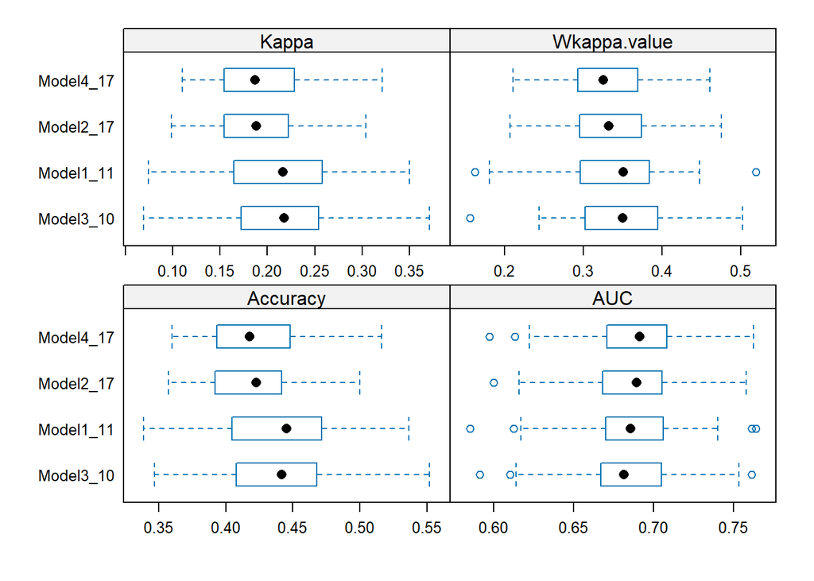

```r
names(vcrTodosModelos)<-paste0("Model",1:length(modelos), "_",sapply(modelos,function(x) x$edf))
bwplot(resamples(vcrTodosModelos),metric=c("AUC","Kappa","Accuracy","Wkappa.value"),
       scales = list(x = list(relation = "free")))
```

```r
summary(resamples(vcrTodosModelos),metric=c("AUC","Kappa","Accuracy","Wkappa.value"))
```

```
Call:
summary.resamples(object = resamples(vcrTodosModelos), metric =
 c("AUC", "Kappa", "Accuracy", "Wkappa.value"))

Models: Model1_11, Model2_17, Model3_10, Model4_17
Number of resamples: 100

AUC
               Min.   1st Qu.    Median      Mean   3rd Qu.      Max. NA's
Model1_11 0.5852485 0.6702389 0.6858567 0.6868145 0.7061416 0.7641823    0
Model2_17 0.6002285 0.6684757 0.6893721 0.6882314 0.7054301 0.7579099    0
Model3_10 0.5914135 0.6674673 0.6816280 0.6843980 0.7048366 0.7615330    0
Model4_17 0.5976624 0.6708832 0.6912632 0.6908514 0.7082052 0.7625811    0

Kappa
                Min.   1st Qu.    Median      Mean   3rd Qu.      Max. NA's
Model1_11 0.07412129 0.1646446 0.2164209 0.2122370 0.2574785 0.3502919    0
Model2_17 0.09872836 0.1546579 0.1879026 0.1900882 0.2214593 0.3037493    0
Model3_10 0.06905181 0.1725073 0.2177560 0.2138844 0.2532711 0.3714080    0
Model4_17 0.11021159 0.1545181 0.1869209 0.1914060 0.2281012 0.3214926    0

Accuracy
               Min.   1st Qu.    Median      Mean   3rd Qu.      Max. NA's
Model1_11 0.3387097 0.4056845 0.4453514 0.4388968 0.4715447 0.5365854    0
Model2_17 0.3571429 0.3920000 0.4227642 0.4198510 0.4408871 0.5000000    0
Model3_10 0.3467742 0.4080000 0.4417742 0.4397820 0.4658862 0.5520000    0
Model4_17 0.3600000 0.3943710 0.4176774 0.4210530 0.4480000 0.5161290    0

Wkappa.value
               Min.   1st Qu.    Median      Mean   3rd Qu.      Max. NA's
Model1_11 0.1620553 0.2963662 0.3508436 0.3422856 0.3840005 0.5194446    0
Model2_17 0.2068607 0.2950057 0.3319486 0.3315417 0.3734170 0.4755100    0
Model3_10 0.1556116 0.3030629 0.3497293 0.3491425 0.3942766 0.5021070    0
Model4_17 0.2109375 0.2933794 0.3254369 0.3298699 0.3693378 0.4605263    0
```

Para determinar el mejor modelo, se estudia la capacidad predictiva, variabilidad y número de parámetros de los modelos.

La capacidad predictiva se evalúa observando la mediana. Queremos la mediana más alta para un mejor rendimiento. Observamos como los modelos de 10 y 11 parámetros muestran medianas ligeramente superiores en Kappa y Wkappa y Accuracy

La variabilidad se mide por la dispersión de los resultados. Un modelo será más estable cuanto más estrechos sean su caja y bigotes. Todos los modelos muestran una variabilidad similar pero en general los modelos de más paráemtros parecen tener cajas más estrechas, lo que sugiere mayor estabilidad

Finalmente, el principio de parsimonia sugiere elegir el modelo más simple (con menor número de parámetros) que explique tan bien los datos como un modelo más complejo.

### Modelo BackBIC

Seleccionado el mejor modelo, se obtienen los ODDSratio del mismo y se va a realizar una evaluación y análisis final mediante los datos de prueba

#### ODDSratio

En primer lugar, se observa la exponencial de los coeficientes junto con su significatividad.

```r
stargazer(modeloBackBIC1, type="text", report=('vc*p'), apply.coef=exp, p.auto=F)
```

```
===============================================
                        Dependent variable:
                    ---------------------------
                           Sleep_Quality
-----------------------------------------------
Wake_Up_Time                 1.367***
                            p = 0.0003

Caffeine_Intake              1.564***
                             p = 0.006

Alcohol_Intake               1.526***
                             p = 0.008

Work_Hours                   0.638***
                            p = 0.00001

Travel_Time                  0.586***
                            p = 0.00001

Social_Interactions          3.478***
                             p = 0.000

Blood_Sugar_Level            1.041***
                            p = 0.00001

-----------------------------------------------
Observations                    620
===============================================
Note:               *p<0.1; **p<0.05; ***p<0.01
```

Todos los parámetros son significativos.

La interpretación de los parámetros es la siguiente

- Wake_Up_Time: Por cada hora adicional en que tarde en despertarse, las posibilidades de tener una percepción de calidad de sueño mayor aumentan en un 37%.
- Caffeine_Intake: Por cada taza de café adicional ingerida en el día, las posibilidades de tener una percepción de calidad de sueño mayor aumentan en un 56%.
- Alcohol_Intake: Por cada bebida alcohólica adicional que se tome durante la semana, las posibilidades de tener una percepción de calidad de sueño mayor aumentan en un 53%.
- Work_Hours: Por cada hora adicional que se trabaje, las posibilidades de tener una percepción de calidad de sueño mayor disminuyen en un 36%.
- Travel_Time: Por cada hora adicional que haya que emplear en transporte, las posibilidades de tener una percepción de calidad de sueño mayor disminuyen en un 41%.
- Social_Interactions: Por cada interacción social adicional durante la semana, las posibilidades de tener una percepción de calidad de sueño mayor aumentan casi por 3,5.
- Blood_Sugar_Level: Finalmente, por cada mg/dL adicional de nivel de azúcar en sangre, las posibilidades de tener una percepción de calidad de sueño mayor aumentan en un 4%.

Para completar el estudio de las variables que componen el modelo, se realiza nuevamente el análisis de tipo II, detectando las variables más importantes.

```r
Anova(modeloBackBIC1,type = "II")
```

```
Analysis of Deviance Table (Type II tests)

Response: Sleep_Quality
                    LR Chisq Df Pr(>Chisq)
Wake_Up_Time          13.470  1  0.0002424 ***
Caffeine_Intake        7.684  1  0.0055719 **
Alcohol_Intake         7.119  1  0.0076261 **
Work_Hours            22.784  1  1.813e-06 ***
Travel_Time           23.234  1  1.435e-06 ***
Social_Interactions  127.553  1  < 2.2e-16 ***
Blood_Sugar_Level     22.538  1  2.060e-06 ***
---
Signif. codes:  0 '***' 0.001 '**' 0.01 '*' 0.05 '.' 0.1 ' ' 1
```

### Evaluación del Modelo

Finalmente, se obtienen las medidas de evaluación del modelo

```r
cm_test<-confusionMatrix(table(predict(modeloBackBIC1,newdata=data_test),data_test$Sleep_Quality))
cm_test$table
```

```
            Pobre Aceptable Buena Excelente
  Pobre        14         1     2         0
  Aceptable     3         8     5         0
  Buena        13        26    39        26
  Excelente     2         1     6         7
```

```r
cm_test$overall[1:2]
```

```
 Accuracy     Kappa
0.4444444 0.2047331
```

```r
cm_test$byClass[,1:2]
```

```
                 Sensitivity Specificity
Class: Pobre       0.4375000   0.9752066
Class: Aceptable   0.2222222   0.9316239
Class: Buena       0.7500000   0.3564356
Class: Excelente   0.2121212   0.9250000
```

Se observa que en términos generales no parece ser un muy buen modelo, pues cuenta con una tasa de acierto del 44% y un índice kappa del 20%.

A pesar de que es capaz de detectar de manera bastante sólida cuando una observacion no pertenece a las clases Pobre, Aceptable o Excelente, no se le da especialmente bien clasificar correctamente una observación en ninguna de las clases.

Obtenemos el kappa ponderado para ampliar el estudio

```r
summary(Kappa(cm_test$table))
```

```
            value     ASE    z  Pr(>|z|)
Unweighted 0.2047 0.05332 3.84 1.233e-04
Weighted   0.3254 0.05679 5.73 1.003e-08

Weights:
          [,1]      [,2]      [,3]      [,4]
[1,] 1.0000000 0.6666667 0.3333333 0.0000000
[2,] 0.6666667 1.0000000 0.6666667 0.3333333
[3,] 0.3333333 0.6666667 1.0000000 0.6666667
[4,] 0.0000000 0.3333333 0.6666667 1.0000000
```

## Regresión Multinomial

Como se ha dicho al empezar el modelo de regresion ordinal, también vamos a evaluar el modelo multinomial. Para ello vamos a generar un primer modelo multinomial que contenga todas las variables.

### Modelo Inicial

```r
modeloInicial<-multinom(Sleep_Quality ~ ., data=data_train)
```

Para poder conocer más información del modelo vamos a recurrir a la función summary().

```r
summary(modeloInicial)
```

```
Call:
multinom(formula = Sleep_Quality ~ ., data = data_train)

Coefficients:
          (Intercept)          Age GenderFemale OccupationCreativo y práctico
Aceptable   -9.639836 -0.006934332   -0.8495559                     0.9666152
Buena      -13.819237  0.015928162   -0.8194338                     0.7164468
Excelente  -20.330888 -0.003942244   -0.9808427                    -0.0100921
          OccupationEconómico OccupationPúblico Marital_StatusMarried
Aceptable           1.0376902        0.48750300             0.4833062
Buena               0.6517466        0.39469798             0.3731659
Excelente           0.5877008       -0.01837401             0.5812440
          Marital_StatusDivorced Sleep_Duration Wake_Up_Time    Bed_Time
Aceptable            -10.3821956      0.5827337    0.2640550 0.040579964
Buena                  0.8101448      0.6729822    0.6298243 0.007341599
Excelente              1.3826525      0.7074802    0.4774802 0.252203350
          Physical_Activity Screen_Time Caffeine_Intake Alcohol_Intake
Aceptable         0.3624392  -0.3525726        1.075827      0.2651763
Buena            -0.1470358  -0.2144884        1.153036      0.7576151
Excelente         0.2695785  -0.6775997        1.093747      1.3459492
          Smoking_HabitYes Work_Hours Travel_Time Social_Interactions
Aceptable        0.9207181 -1.4927209   0.1848512          -0.2551996
Buena            0.1843457 -0.9899435  -1.0942389           0.8661008
Excelente       -0.1627461 -1.1038984  -0.8072585           1.5396431
          Meditation_PracticeYes Exercise_TypeCuerpo y Mente
Aceptable              0.5078746                  -0.4924045
Buena                  0.7083076                  -0.5440943
Excelente              0.7698420                  -0.1558168
          Exercise_TypeFuerza Blood_Pressure Cholesterol_Level
Aceptable          -0.3125424     0.03843048        0.05047919
Buena              -0.5352393     0.04430337        0.03631243
Excelente           0.2622745     0.10722496       -0.03643194
          Blood_Sugar_Level Stress_DetectionMedium Stress_DetectionHigh
Aceptable       -0.02081721             -0.2928292           -1.2009229
Buena           -0.01282188             -0.1993820           -0.3135391
Excelente        0.06093724             -0.6611625           -0.7370610

Std. Errors:
          (Intercept)        Age GenderFemale OccupationCreativo y práctico
Aceptable  0.02804016 0.02650572    0.3779018                     0.4539714
```

[output cut: 18 more lines]

```
          Meditation_PracticeYes Exercise_TypeCuerpo y Mente
Aceptable              0.4464856                   0.4674660
Buena                  0.3297740                   0.4064315
Excelente              0.3883015                   0.4658422
          Exercise_TypeFuerza Blood_Pressure Cholesterol_Level
Aceptable           0.4515821     0.03434679        0.03201360
Buena               0.4107217     0.02834662        0.02539155
Excelente           0.4580134     0.03264315        0.02980697
          Blood_Sugar_Level Stress_DetectionMedium Stress_DetectionHigh
Aceptable        0.04585855              0.4511677            0.5748418
Buena            0.03836782              0.3671794            0.4411922
Excelente        0.04525401              0.4385469            0.5082228

Residual Deviance: 1205.946
AIC: 1367.946
```

Como se mencionaba y debido a la naturaleza de este tipo de modelos, hablar sobre los valores de los parámetros y como afectan a cada categoría de la variable objetivo respecto a la categoría de referencia (Pobre) se hace un proceso costoso y largo.

Para poder comparar con el resultado obtenido a partir de la regresión ordinal se procede a crear los modelos automáticos y seleccionar el mejor de los mismos

### Modelo Automático

```r
null <- multinom(Sleep_Quality ~ 1, data = data_train, trace=F)
full <- multinom(Sleep_Quality ~ ., data = data_train, trace=F)
invisible(capture.output({ # Esto se incluye para evitar la aparición del texto "trying..."
  modeloStepBIC<-step(null, scope=list(lower=null, upper=full), direction="both", k=log(nrow(data_train)), trace=F)
  modeloStepAIC<-step(null, scope=list(lower=null, upper=full), direction="both", k=2, trace=F)
  modeloForwBIC<-step(null, scope=list(lower=null, upper=full), direction="forward", k=log(nrow(data_train)),trace=F)
  modeloForwAIC<-step(null, scope=list(lower=null, upper=full), direction="forward", k=2, trace=F)
  modeloBackBIC<-step(full, scope=list(lower=null, upper=full), direction="backward", k=log(nrow(data_train)),trace=F)
  modeloBackAIC<-step(full, scope=list(lower=null, upper=full), direction="backward", k=2, trace=F)
}))
modelos<-list(modeloStepBIC,modeloStepAIC,modeloForwBIC,modeloForwAIC,modeloBackBIC,modeloBackAIC)
map(modelos,function(x) x$call)
```

```
[[1]]
multinom(formula = Sleep_Quality ~ Social_Interactions + Blood_Pressure +
    Wake_Up_Time + Travel_Time + Work_Hours + Caffeine_Intake,
    data = data_train, trace = F)

[[2]]
multinom(formula = Sleep_Quality ~ Social_Interactions + Blood_Pressure +
    Wake_Up_Time + Travel_Time + Work_Hours + Caffeine_Intake +
    Alcohol_Intake + Cholesterol_Level + Gender + Smoking_Habit +
    Meditation_Practice + Sleep_Duration + Marital_Status, data = data_train,
    trace = F)

[[3]]
multinom(formula = Sleep_Quality ~ Social_Interactions + Blood_Pressure +
    Wake_Up_Time + Travel_Time + Work_Hours + Caffeine_Intake,
    data = data_train, trace = F)

[[4]]
multinom(formula = Sleep_Quality ~ Social_Interactions + Blood_Pressure +
    Wake_Up_Time + Travel_Time + Work_Hours + Caffeine_Intake +
    Alcohol_Intake + Cholesterol_Level + Gender + Smoking_Habit +
    Meditation_Practice + Sleep_Duration + Marital_Status, data = data_train,
    trace = F)

[[5]]
multinom(formula = Sleep_Quality ~ Gender + Marital_Status +
    Sleep_Duration + Wake_Up_Time + Caffeine_Intake + Alcohol_Intake +
    Smoking_Habit + Work_Hours + Travel_Time + Social_Interactions +
    Meditation_Practice + Blood_Pressure + Cholesterol_Level,
    data = data_train, trace = F)

[[6]]
multinom(formula = Sleep_Quality ~ Gender + Marital_Status +
    Sleep_Duration + Wake_Up_Time + Caffeine_Intake + Alcohol_Intake +
    Smoking_Habit + Work_Hours + Travel_Time + Social_Interactions +
    Meditation_Practice + Blood_Pressure + Cholesterol_Level,
    data = data_train, trace = F)
```

```r
map_int(modelos,function(x) x$edf)
```

```
[1] 21 45 21 45 45 45
```

En esta ocasión se obtienen 2 modelos, con 21 y 45 parámetros respectivamente.

Para poder determinar cuál de los modelos es mejor, se va a recurrir a la validación cruzada repetida, gracias a la cual se podran evaluar los modelos mediante las medidas ya estudiadas.

```r
my_summary  <- function(data, lev = NULL, model = NULL){
  a1 <- multiClassSummary(data, lev, model)
  b1 <- vcd::Kappa(table(data[, "pred"],data[, "obs"]))$Weighted[1]
  out <- c(a1, Wkappa=b1)
  out
}
modelos<-list(modeloForwBIC, modeloForwAIC)
vcrTodosModelos<-list()
for (i in 1:length(modelos)){
  set.seed(1712)
  vcr <- caret::train (formula(modelos[[i]]),
                data = data_train, method = "polr",
                tuneGrid = expand.grid(method="logistic"),
                trControl = trainControl(method = "repeatedcv",
                                         number = 5, repeats=20,
                                         classProbs = TRUE,
                                         summaryFunction = my_summary)
  )
  vcrTodosModelos[[i]]<-vcr
}
```

A continuación, se representan en diagramas de cajas y se obtienen algunos estadísticos de las repeticiones

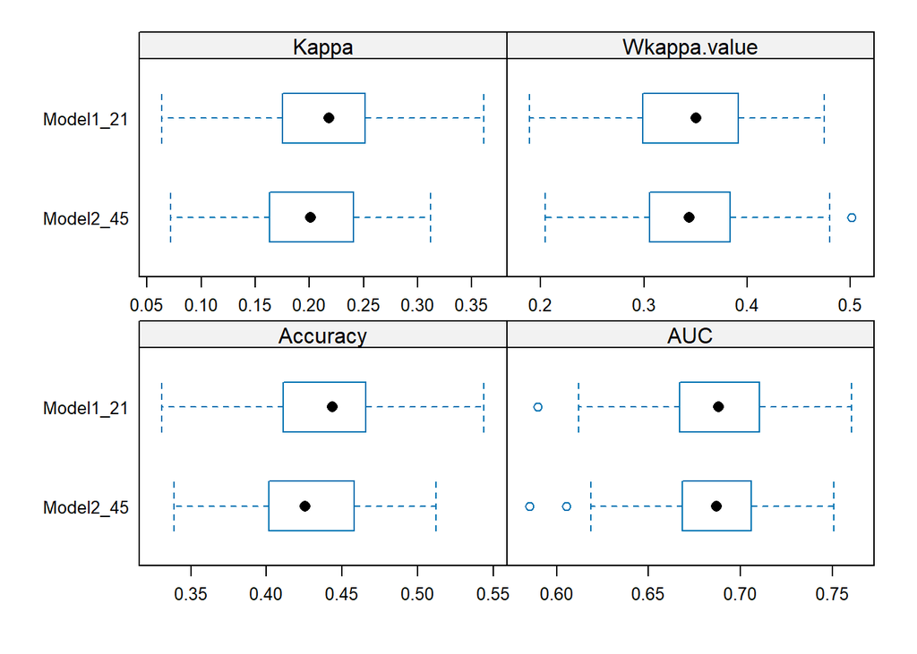

```r
names(vcrTodosModelos)<-paste0("Model",1:length(modelos), "_",sapply(modelos,function(x) x$edf))
bwplot(resamples(vcrTodosModelos),metric=c("AUC","Kappa","Accuracy","Wkappa.value"),
       scales = list(x = list(relation = "free")))
```

```r
summary(resamples(vcrTodosModelos),metric=c("AUC","Kappa","Accuracy","Wkappa.value"))
```

```
Call:
summary.resamples(object = resamples(vcrTodosModelos), metric =
 c("AUC", "Kappa", "Accuracy", "Wkappa.value"))

Models: Model1_21, Model2_45
Number of resamples: 100

AUC
               Min.   1st Qu.    Median      Mean   3rd Qu.      Max. NA's
Model1_21 0.5898264 0.6669773 0.6879562 0.6869375 0.7102239 0.7604921    0
Model2_45 0.5851239 0.6690485 0.6868226 0.6854664 0.7059867 0.7508426    0

Kappa
                Min.   1st Qu.    Median      Mean   3rd Qu.      Max. NA's
Model1_21 0.06346136 0.1750472 0.2180600 0.2127896 0.2513802 0.3614447    0
Model2_45 0.07200876 0.1631936 0.2012339 0.2021320 0.2410507 0.3118881    0

Accuracy
               Min.   1st Qu.    Median      Mean   3rd Qu.      Max. NA's
Model1_21 0.3306452 0.4112903 0.4435484 0.4375301 0.4649355 0.5440000    0
Model2_45 0.3387097 0.4024194 0.4257097 0.4289588 0.4569194 0.5121951    0

Wkappa.value
               Min.   1st Qu.    Median      Mean   3rd Qu.      Max. NA's
Model1_21 0.1888423 0.2991006 0.3508623 0.3454874 0.3909556 0.4750284    0
Model2_45 0.2046462 0.3059767 0.3443147 0.3435121 0.3832081 0.5016734    0
```

Por el principio de parsimonia y a la vista de la falta de diferencia tanto en capacidad predictiva como en variabilidad, optamos por el modelo con menor número de parámetros formulado a través de ForwBIC.

### Modelo ForwBIC

Seleccionado el mejor modelo, se obtienen los ODDSratio del mismo y se va a realizar una evaluación y análisis final mediante los datos de prueba

#### ODDSratio

En primer lugar, se observa la exponencial de los coeficientes junto con su significatividad.

```r
stargazer(modeloForwBIC, type="text", report=('vc*p'), apply.coef=exp, p.auto=F)
```

```
=======================================================
                            Dependent variable:
                    -----------------------------------
                     Aceptable     Buena     Excelente
                        (1)         (2)         (3)
-------------------------------------------------------
Social_Interactions    1.048     3.335***    6.974***
                     p = 0.854   p = 0.000   p = 0.000

Blood_Pressure       1.090***    1.093***    1.118***
                    p = 0.00000  p = 0.000   p = 0.000

Wake_Up_Time          1.258*     1.971***    1.790***
                     p = 0.093  p = 0.00000 p = 0.00005

Travel_Time            1.295     0.365***    0.428***
                     p = 0.341  p = 0.00001 p = 0.0005

Work_Hours           0.395***    0.613***    0.538***
                    p = 0.00001 p = 0.0003  p = 0.0003

Caffeine_Intake      2.292***    2.796***    2.826***
                     p = 0.006  p = 0.00005 p = 0.0004

Constant             0.0003***  0.00000***   0.000***
                    p = 0.00001  p = 0.000   p = 0.000

-------------------------------------------------------
Akaike Inf. Crit.    1,364.713   1,364.713   1,364.713
=======================================================
Note:                       *p<0.1; **p<0.05; ***p<0.01
```

```r
Anova(modeloBackBIC, type = "II")
```

```
Analysis of Deviance Table (Type II tests)

Response: Sleep_Quality
                    LR Chisq Df Pr(>Chisq)
Gender                 9.165  3  0.0271791 *
Marital_Status        12.899  6  0.0446648 *
Sleep_Duration         8.625  3  0.0347140 *
Wake_Up_Time          18.581  3  0.0003337 ***
Caffeine_Intake       18.957  3  0.0002790 ***
Alcohol_Intake        14.253  3  0.0025807 **
Smoking_Habit          9.414  3  0.0242613 *
Work_Hours            48.947  3  1.339e-10 ***
Travel_Time           47.481  3  2.745e-10 ***
Social_Interactions   68.047  3  1.118e-14 ***
Meditation_Practice    7.452  3  0.0588145 .
Blood_Pressure         8.560  3  0.0357511 *
Cholesterol_Level      7.469  3  0.0583623 .
---
Signif. codes:  0 '***' 0.001 '**' 0.01 '*' 0.05 '.' 0.1 ' ' 1
```

En este caso, se obtiene para cada variable como influye en cada una de las categorías de la variable objetivo Sleep_Quality a partir de la categoría de referencia Pobre.

### Evaluación del Modelo

Finalmente, se obtienen las medidas de evaluación del modelo

```r
cm_test<-confusionMatrix(table(predict(modeloForwBIC,newdata=data_test),data_test$Sleep_Quality))
cm_test$table
```

```
            Pobre Aceptable Buena Excelente
  Pobre        13         1     9         2
  Aceptable     5        23    11         7
  Buena        12         8    27        15
  Excelente     2         4     5         9
```

```r
cm_test$overall[1:2]
```

```
 Accuracy     Kappa
0.4705882 0.2739469
```

```r
Kappa(cm_test$table)
```

```
            value     ASE     z  Pr(>|z|)
Unweighted 0.2739 0.05487 4.993 5.959e-07
Weighted   0.2746 0.06184 4.440 8.989e-06
```

```r
cm_test$byClass[,1:2]
```

```
                 Sensitivity Specificity
Class: Pobre       0.4062500   0.9008264
Class: Aceptable   0.6388889   0.8034188
Class: Buena       0.5192308   0.6534653
Class: Excelente   0.2727273   0.9083333
```

### Hipótesis de proporcionalidad

Vamos a evaluar un modelo multinomial con las mismas variables que hemos obtenido en el mejor modelo ordinal

```r
modelo_multinom<-multinom(formula(modeloBackBIC1), data=data_train)
cm_test_multi<-confusionMatrix(table(predict(modelo_multinom,newdata=data_test),data_test$Sleep_Quality))
cm_test_multi$overall[1]
```

```
 Accuracy
0.5098039
```

```r
Kappa(cm_test_multi$table)
```

```
            value     ASE     z  Pr(>|z|)
Unweighted 0.3263 0.05407 6.035 1.592e-09
Weighted   0.3336 0.06007 5.554 2.789e-08
```

```r
lrtest(modeloBackBIC,modelo_multinom)
```

```
Likelihood ratio test

Model 1: Sleep_Quality ~ Gender + Marital_Status + Sleep_Duration + Wake_Up_Time +
    Caffeine_Intake + Alcohol_Intake + Smoking_Habit + Work_Hours +
    Travel_Time + Social_Interactions + Meditation_Practice +
    Blood_Pressure + Cholesterol_Level
Model 2: Sleep_Quality ~ Wake_Up_Time + Caffeine_Intake + Alcohol_Intake +
    Work_Hours + Travel_Time + Social_Interactions + Blood_Sugar_Level
  #Df  LogLik  Df  Chisq Pr(>Chisq)
1  45 -624.94
2  24 -652.92 -21 55.965  5.106e-05 ***
---
Signif. codes:  0 '***' 0.001 '**' 0.01 '*' 0.05 '.' 0.1 ' ' 1
```

Visto como ninguno de los dos modelos funciona especialmente bien para nuestra base de datos, procedemos a trabajar modelos de predicción basados en árboles

# Modelo Árboles

En esta ocasión y de manera análoga a lo que sucedía con los modelos GLM podemos realizar árboles tanto ordinales como de clasificación.

Los árboles ordinales están especialmente diseñados para variables categóricas ordinales. Es importante destacar que aunque es posible construir modelos de clasificación para variables ordinales ignorando la componente ordinal, si el orden de los niveles es importante, como sucede en nuestro caso, es preferible optar por estos pues están diseñados para respetar dicho orden, por lo que sólo se realizarán árboles de este tipo

## Recodificación de la variable

La función que genera los árboles ordinales precisa que las variables dependientes estén codificadas como numéricas asignando un número según el orden de menor a mayor.

Una vez este codificada correctamente, se realiza nuevamente la partición entrenamiento prueba

```r
datos$Sleep_Quality<-car::recode(datos$Sleep_Quality, as.factor = FALSE,
                              "'Pobre'=1;'Aceptable'=2;'Buena'=3;'Excelente'=4")

set.seed(12345)
trainIndex <- createDataPartition(datos$Sleep_Quality, p=0.8, list=FALSE)
data_ord_train <- datos[trainIndex,]
data_ord_test <- datos[-trainIndex,]
```

## Modelo Inicial

Para ver una primera modelización, vamos a partir de un árbol con tamaño de hoja mínimo del 5%, indicando que no realice la poda ni obtenga reglas sustitutas.

A partir de este árbol generaremos más adelante otros para poder determinar el tamaño mínimo de hoja, parámetro de la poda y número de reglas sustitutas que mejor nos puedan ayudar en un futuro a tomar decisiones

```r
set.seed(12345)
arbolOrd5 <- rpartScore(Sleep_Quality~., data = data_ord_train,
                       minbucket=ceiling(0.05*nrow(data_ord_train)),
                       cp=0, maxsurrogate = 0, maxcompete=0)
sum(arbolOrd5$frame$var == "<leaf>")
```

```
[1] 11
```

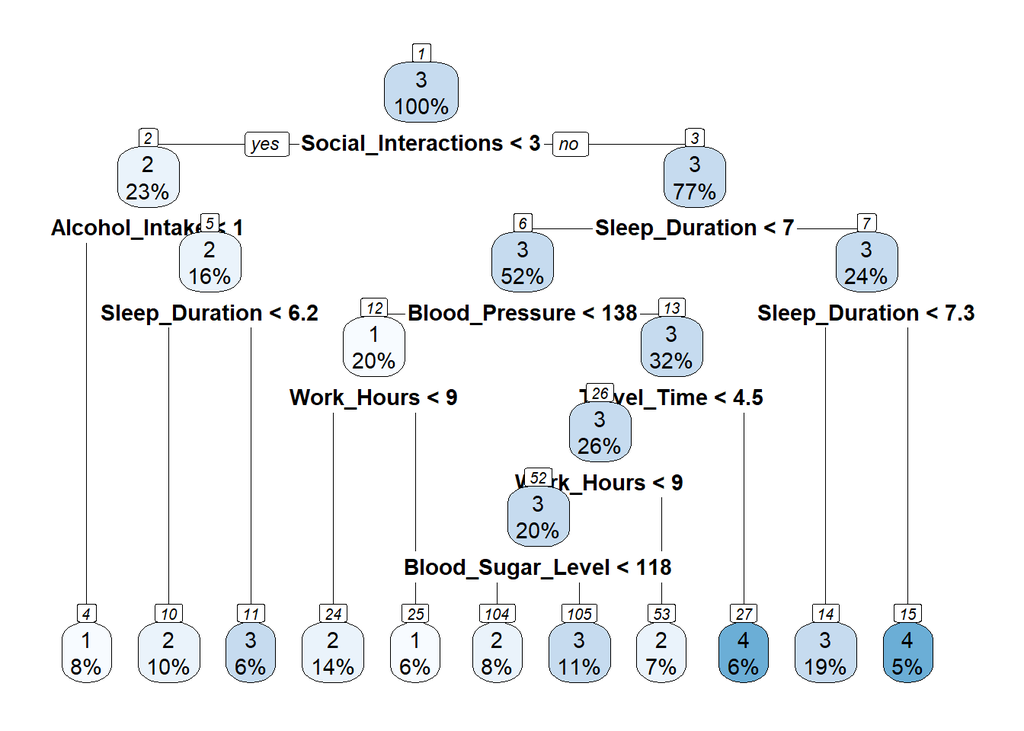

```r
rpart.plot(arbolOrd5, nn=TRUE, tweak = 1.2)
```

Vemos que se ha construido un árbol con 11 hojas y una profundidad de 6, y que el resultado aparece con una gama de colores donde los claros corresponden con los niveles bajos de la variable, es decir calidad de sueño percibida Pobre o Aceptable y los oscuros son los altos, Buena o Excelente.

Cada nodo muestra la categoría predicha y observamos que al menos hay dos nodos para cada categoría.

Aquellos con mejor percepción de calidad de sueño son aquellos que han tenido más de 3 interacción sociales en la semana y han dormido más de 7.3 horas o, habiendo dormido menos de 7 horas, contaban con un nivel de presión en sangre mayor a 138 y habían empleado en transporte más de 4,5h.

Sin embargo, para asegurar el mejor árbol posible, es preferible dejar que crezca siendo más flexibles con el tamaño mínimo de hoja y asi poder podarlo. Por ello, construimos un arbol con el 1%.

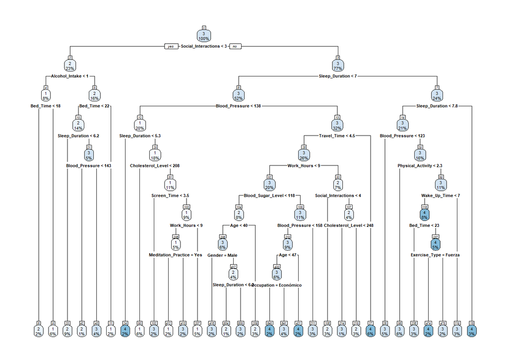

```r
set.seed(12345)
arbolOrd1 <- rpartScore(Sleep_Quality~., data = data_ord_train,
                       minbucket=ceiling(0.01*nrow(data_ord_train)),
                       cp=0, maxsurrogate = 0, maxcompete=0)
rpart.plot(arbolOrd1, nn=TRUE, tweak = 1.2)
```

Ahora el árbol es prácticamente imposible de ver ya que es muy grande.

Obtenemos una serie de métricas para ver las diferencias entre este árbol y el anterior

```r
modelos<-list(arbolOrd5,arbolOrd1)

sapply(modelos,
       function(x) Kappa(table(factor(predict(x,newdata=data_ord_train),1:max(data_ord_train$Sleep_Quality)), data_ord_train$Sleep_Quality))$Weighted[1])
```

```
    value     value
0.5076934 0.6758188
```

```r
sapply(modelos,
       function(x) Kappa(table(factor(predict(x, newdata=data_ord_test),1:max(data_ord_test$Sleep_Quality)),data_ord_test$Sleep_Quality))$Weighted[1])
```

```
    value     value
0.3714540 0.4504643
```

```r
sapply(modelos,function(x) sum(x$frame$var == "<leaf>"))
```

```
[1] 11 31
```

Hemos construido un árbol con 31 hojas pero que permite aumentar el índice kappa ponderado significativamente tanto en entrenamiento como en prueba.

De igual manera, ha aumentado el sobreajuste, por lo que vamos a podar el árbol para procurar conseguir un tamaño de árbol más manejable, con similar capacidad predictiva y, a poder ser, reduciendo el sobreajuste.

## Poda del Árbol

```r
arbolOrd1$cptable
```

```
            CP nsplit rel error    xerror       xstd
1  0.144688645      0 1.0000000 1.0000000 0.02839714
2  0.049450549      1 0.8553114 0.8553114 0.02998857
3  0.045787546      4 0.7069597 0.8223443 0.03593199
4  0.031135531      5 0.6611722 0.7051282 0.02514566
5  0.024725275      6 0.6300366 0.6758242 0.01980225
6  0.019230769      8 0.5805861 0.6355311 0.02551644
7  0.016483516     10 0.5421245 0.6465201 0.02766114
8  0.008241758     12 0.5091575 0.6007326 0.03587126
9  0.007326007     14 0.4926740 0.5952381 0.03981147
10 0.006410256     15 0.4853480 0.5952381 0.03981147
11 0.005494505     17 0.4725275 0.5842491 0.03113014
12 0.004120879     20 0.4560440 0.5824176 0.03201725
13 0.003663004     24 0.4395604 0.5787546 0.03163784
14 0.001831502     28 0.4249084 0.5842491 0.03058663
15 0.000000000     30 0.4212454 0.6007326 0.03106002
```

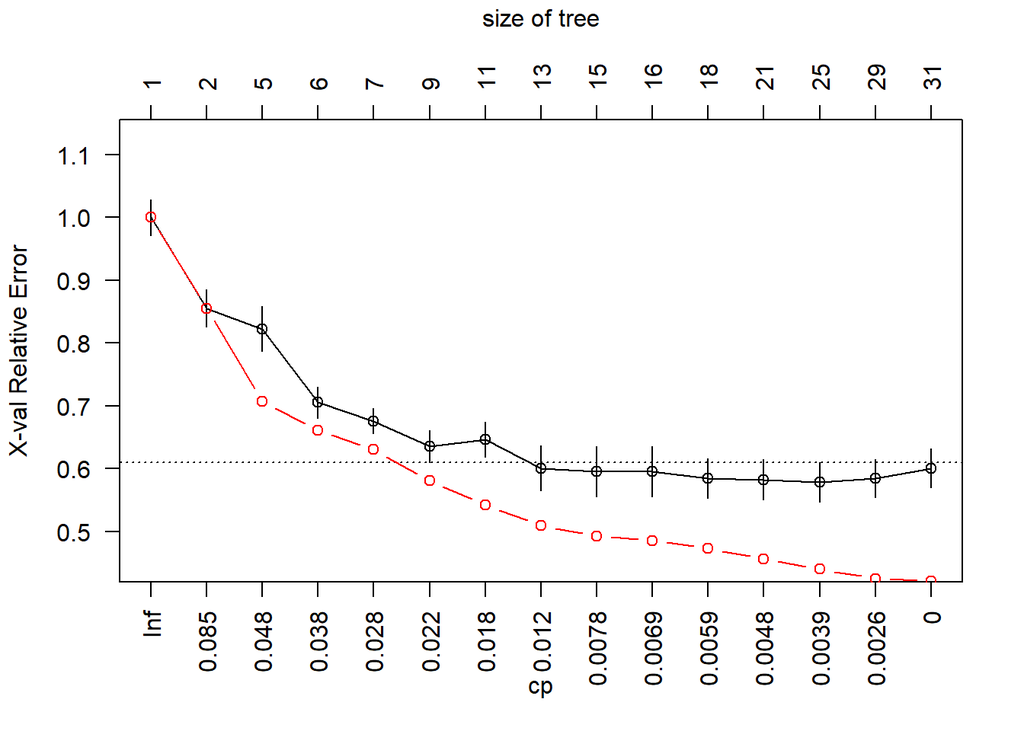

```r
plotcp(arbolOrd1, las=2)
lines(arbolOrd1$cptable[,3], col="red", type = "b")
```

Se observa la mejora relativa. Se observa que a partir de las 13 hojas el error relativo no disminuye significativamente, por lo que podríamos podar el árbol a ese tamaño.

No obstante y teniendo en cuenta que en árboles se persigue el equilibrio entre la interpretabilidad y capacidad predictiva, un tamaño de 9 también podría ser razonable.

Respecto al sobreajuste, se observa que este es menor en 9 hojas respecto a 13.

Dado que la métrica graficada puede ser algo confusa, generamos una métrica para ver como varía el kappa ponderado en función del número de hojas

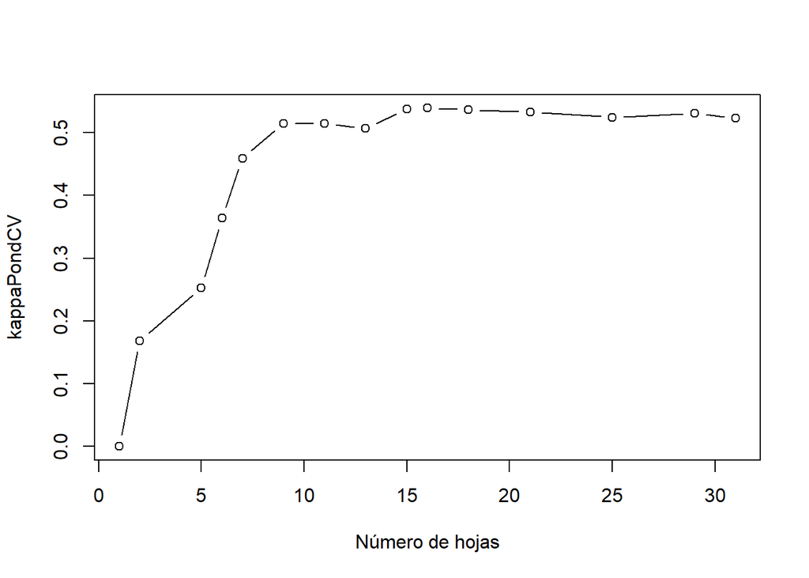

```r
set.seed(12345)
CVresults<-xpred.rpart(arbolOrd1, return.all =T)
kappaPondCV<-apply(CVresults, 2,
                function(x) Kappa(table(factor(x,1:max(data_ord_train$Sleep_Quality)),
                                        data_ord_train$Sleep_Quality))$Weighted[1])
plot(arbolOrd1$cptable[,2]+1, kappaPondCV, type="b", xlab = "Número de hojas")
```

Como estamos trabajando con una variable ordinal, lo más conveniente es recurrir al kappa ponderado. Viendo el gráfico volvemos a los mismos resultados, a partir de las 13 hojas apenas hay mejoras pero con 9 hojas también se pueden obtener buenos resultados.

Por tanto, procedemos a llevar a cabo dicha poda escribiendo manualmente el valor de alpha para 9 hojas

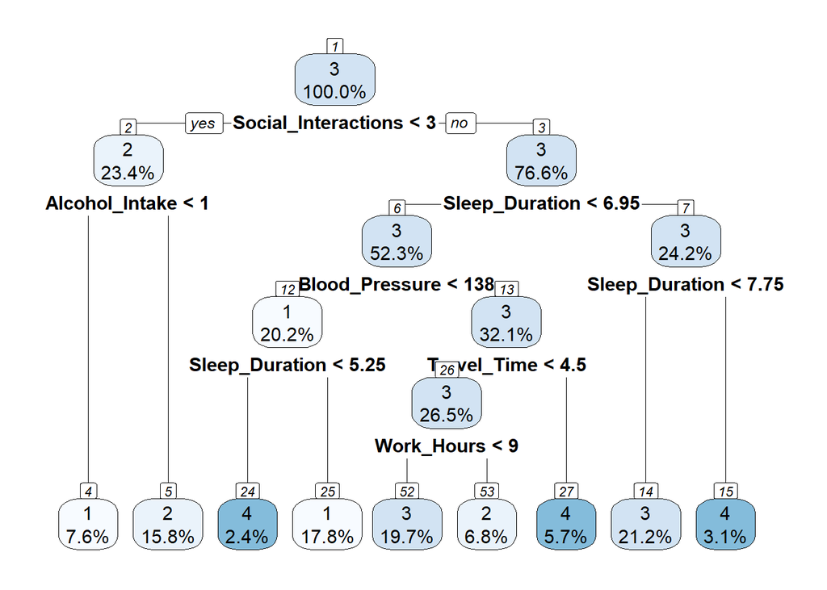

```r
arbolOrd1_podado<-prune(arbolOrd1,cp=0.022)
rpart.plot(arbolOrd1_podado, nn=TRUE, tweak=1.1, digits=3)
```

Observamos un árbol de 9 hojas y profundidad de 5, con hojas de distinta tonalidades.

Se observa como 3 de ellas están asociadas a calidad de sueño percibida Excelente, y el resto de categorías tienen 2 hojas asociadas cada una de ellas.

## Grado de Credibilidad

Para conocer el grado de credibilidad de las predicciones, creamos una nueva representación gráfica del árbol donde se muestra un gráfico de barras para cada hoja

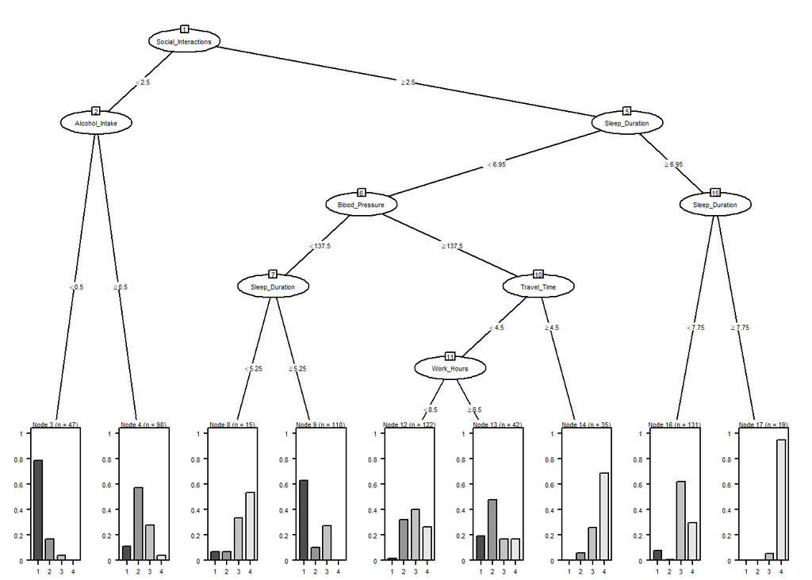

```r
plot(as.party(arbolOrd1_podado), gp = gpar(fontsize = 4), terminal_panel = node_barplot)
```

## Evaluación del Modelo

Finalemnte, realizamos una evaluación del modelo generado tanto para el conjunto de entrenamiento como para el de prueba

```r
cm<-confusionMatrix(table(factor(predict(arbolOrd1_podado, newdata=data_ord_train),1:max(data_ord_train$Sleep_Quality)),data_ord_train$Sleep_Quality))
cm$overall[1]
```

```
 Accuracy
0.5848142
```

```r
Kappa(cm$table)
```

```
            value     ASE     z   Pr(>|z|)
Unweighted 0.4312 0.02717 15.87  9.965e-57
Weighted   0.5502 0.02480 22.18 5.011e-109
```

```r
cm$byClass[,1:2]
```

```
         Sensitivity Specificity
Class: 1   0.7681159   0.8939709
Class: 2   0.5507246   0.8669439
Class: 3   0.6161137   0.6985294
Class: 4   0.3787879   0.9609856
```

```r
cm_test<-confusionMatrix(table(factor(predict(arbolOrd1_podado, newdata=data_ord_test),1:max(data_ord_test$Sleep_Quality)),data_ord_test$Sleep_Quality))
cm_test$overall[1]
```

```
Accuracy
0.474026
```

```r
Kappa(cm_test$table)
```

```
            value     ASE     z  Pr(>|z|)
Unweighted 0.2826 0.05580 5.066 4.067e-07
Weighted   0.4109 0.05436 7.560 4.033e-14
```

```r
cm_test$byClass[,1:2]
```

```
         Sensitivity Specificity
Class: 1   0.7692308   0.8593750
Class: 2   0.4186047   0.8108108
Class: 3   0.4615385   0.6568627
Class: 4   0.3333333   0.9421488
```

## Importancia de las Variables

Por último, vamos a obtener la importancia de las variables del modelo donde, haciendo uso de la información sobre las divisiones que forman parte del árbol multiplicamos la mejora del índice y el número de observaciones del nodo y las agregamos por variable

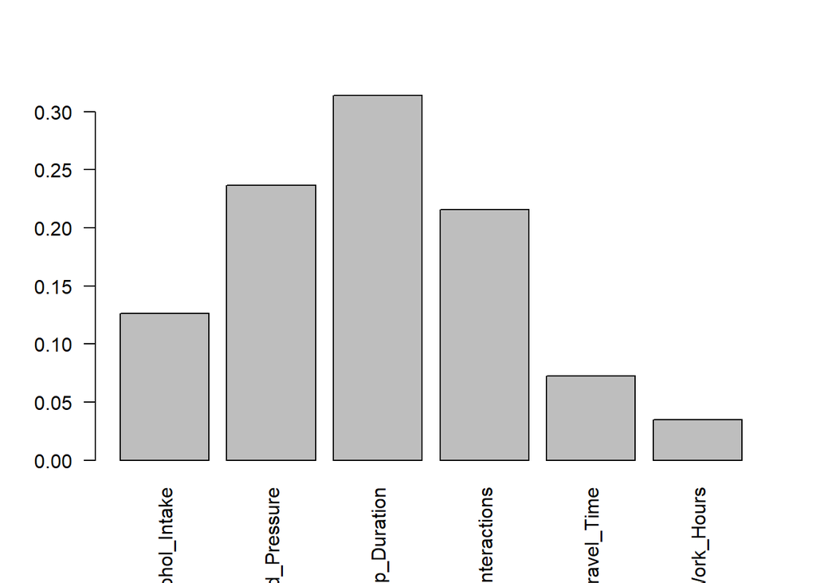

```r
auxImportancia<-data.frame(arbolOrd1_podado$splits,
                           variable=rownames(arbolOrd1_podado$splits))
impVar<-aggregate(count*improve~variable, auxImportancia, sum)
barplot(impVar$`count * improve`/sum(impVar$`count * improve`),
        names.arg=impVar$var, las=2)
```

Cabe destacar que se pueden generar reglas sustitutas y, en caso de tener datos faltantes para alguna de las “preguntas” puede ser útil en vez de directamente asociar la observación con la categoría que mayor porcentaje de observaciones contenga

```r
set.seed(12345)
arbolOrd1_pod_miss <- rpartScore(Sleep_Quality~., data = data_ord_train,
                                 minbucket=ceiling(0.01*nrow(data_ord_train)),
                                 cp=0.022, maxsurrogate = 2, maxcompete=0)
summary(arbolOrd1_pod_miss)
```

```
Call:
rpartScore(formula = Sleep_Quality ~ ., data = data_ord_train,
    minbucket = ceiling(0.01 * nrow(data_ord_train)), cp = 0.022,
    maxsurrogate = 2, maxcompete = 0)
  n= 619

          CP nsplit rel error    xerror       xstd
1 0.14468864      0 1.0000000 1.0000000 0.03817265
2 0.04945055      1 0.8553114 0.8553114 0.03162193
3 0.04578755      4 0.7069597 0.8553114 0.03183338
4 0.03113553      5 0.6611722 0.7472527 0.03549524
5 0.02472527      6 0.6300366 0.6721612 0.03397424
6 0.02200000      8 0.5805861 0.6318681 0.03438642

Variable importance
     Sleep_Duration         Travel_Time          Work_Hours      Alcohol_Intake
                 19                  14                  13                  11
     Blood_Pressure   Blood_Sugar_Level         Screen_Time     Caffeine_Intake
                 11                   8                   8                   8
Social_Interactions   Cholesterol_Level    Stress_Detection
                  5                   4                   1

Node number 1: 619 observations,    complexity param=0.1446886
  predicted score= 3   expected loss= 0.88206785
  left son=2 (145 obs) right son=3 (474 obs)
  Primary splits:
      Social_Interactions < 2.5   to the left,  improve=0.09347201, (0 missing)
  Surrogate splits:
      Work_Hours        < 7.5   to the left,  agree=0.887, adj=0.517, (0 split)
      Cholesterol_Level < 172.5 to the left,  agree=0.772, adj=0.028, (0 split)

Node number 2: 145 observations,    complexity param=0.04945055
  predicted score= 2   expected loss= 0.58620690
  left son=4 (47 obs) right son=5 (98 obs)
  Primary splits:
      Alcohol_Intake < 0.5   to the left,  improve=0.2331931, (0 missing)
  Surrogate splits:
      Screen_Time     < 3.5   to the left,  agree=0.903, adj=0.702, (0 split)
      Caffeine_Intake < 1.5   to the left,  agree=0.897, adj=0.681, (0 split)

```

[output cut: 64 more lines]

```
  left son=52 (122 obs) right son=53 (42 obs)
  Primary splits:
      Work_Hours < 8.5   to the left,  improve=0.05667594, (0 missing)
  Surrogate splits:
      Cholesterol_Level < 242.5 to the left,  agree=0.933, adj=0.738, (0 split)
      Blood_Sugar_Level < 127.5 to the left,  agree=0.890, adj=0.571, (0 split)

Node number 27: 35 observations
  predicted score= 4   expected loss= 0.37142857

Node number 52: 122 observations
  predicted score= 3   expected loss= 0.61475410

Node number 53: 42 observations
  predicted score= 2   expected loss= 0.69047619
```

# Modelo Random Forest

A continuación, vamos a generar un modelo RF, donde se introduce cierta aleatoriedad a la hora de generar los árboles para que entre ellos haya menor correlación y, por tanto, una mejora de la capacidad predictiva.

Debido a la naturaleza de nuestra variable objetivo, haremos uso de bosques aleatorios para clasificación donde nos centraremos en predecir si los individuos pertenecen a una categoría u otra.

En este caso, nos tenemos que asegurar de que la variable es de tipo factor. Como en el apartado anterior la hemos codificado como númerica que toma valores 1,2,3 y 4 basta con pasarla nuevamente a factor

```r
datos$Sleep_Quality <- as.factor(datos$Sleep_Quality)
```

Nuevamente y antes de comenzar con la modelización, llevamos a cabo la partición entrenamiento-prueba

```r
set.seed(12345)
trainIndex <- createDataPartition(datos$Sleep_Quality, p=0.8, list=FALSE)
data_clasif_train <- datos[trainIndex,]
data_clasif_test <- datos[-trainIndex,]
```

## Modelo Inicial

Comenzamos creando un RF de 500 árboles con un tamaño de hoja equivalente al 5% con ntree y mtry por defecto, que es equivalente a la raíz cuadrada del número de variables explicativas disponibles

```r
set.seed(12345)
RF5<-randomForest(Sleep_Quality~., data=data_clasif_train, keep.inbag = TRUE,
                                 nodesize=ceiling(0.05*nrow(data_clasif_train)))
print(RF5)
```

```
Call:
 randomForest(formula = Sleep_Quality ~ ., data = data_clasif_train,      keep.inbag = TRUE, nodesize = ceiling(0.05 * nrow(data_clasif_train)))
               Type of random forest: classification
                     Number of trees: 500
No. of variables tried at each split: 4

        OOB estimate of  error rate: 41.77%
Confusion matrix:
   1  2   3  4 class.error
1 99 12  21  0   0.2500000
2 27 95  19  4   0.3448276
3 26 53 117 15   0.4454976
4  4 18  60 50   0.6212121
```

Como podemos observar, el modelo da lugar a una tasa de error de 41.77% en las observaciones OOB (out of the bag), es decir, con observaciones que no ha visto o seleccionado para la creación de árboles, una especie de “set de validación”.

Es una tasa bastante elevada puesto que es casi la mitad del dataset.

## Selección de Parámetros

Vamos a ir modificando los distintos parámetros para que tenga mejor capacidad predictiva y elimine lo máximo posible el sobreajuste.

Para estudiar el número óptimo de árboles, vamos a recurrir a la librería OOBcurve que permite hacerlo a partir de medidas diferentes a la tasa de error.

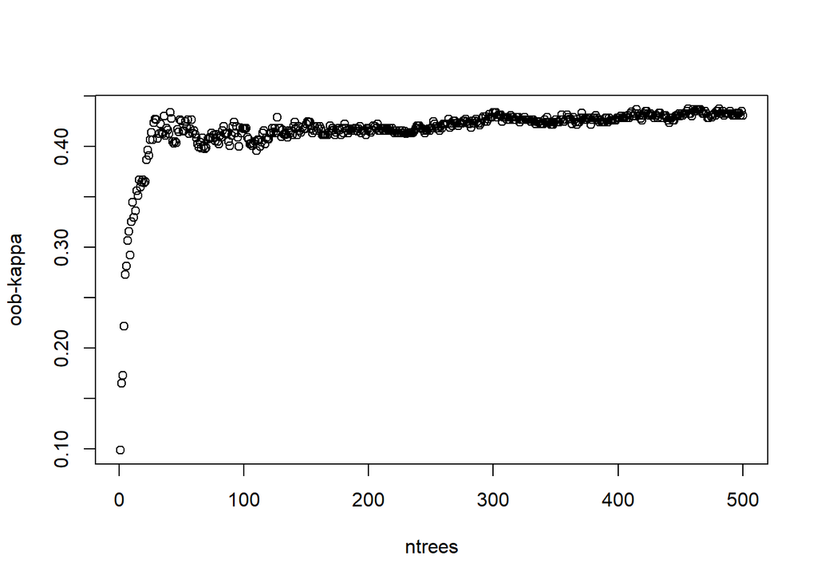

```r
auxtask <- makeClassifTask(data = data_clasif_train, target = "Sleep_Quality")
results_5 <- OOBCurve(RF5, measures = list(kappa),
                    task = auxtask, data = data_clasif_train)

plot(results_5$kappa, ylab = "oob-kappa", xlab = "ntrees")
```

```r
results_5$kappa[c(1,50,100,200,300,400,500)]
```

```
[1] 0.09867621 0.42522310 0.41745584 0.41775200 0.43373405 0.42837765 0.43072865
```

A partir de los resultados se observa que los mejores se obtienen para unos 300 árboles pero a partir de los 50 el cambio es bastante ligero.

Vamos a probar a continuación a reducir el tamaño de hoja para determinar si se puede dar lugar a mejores resultados

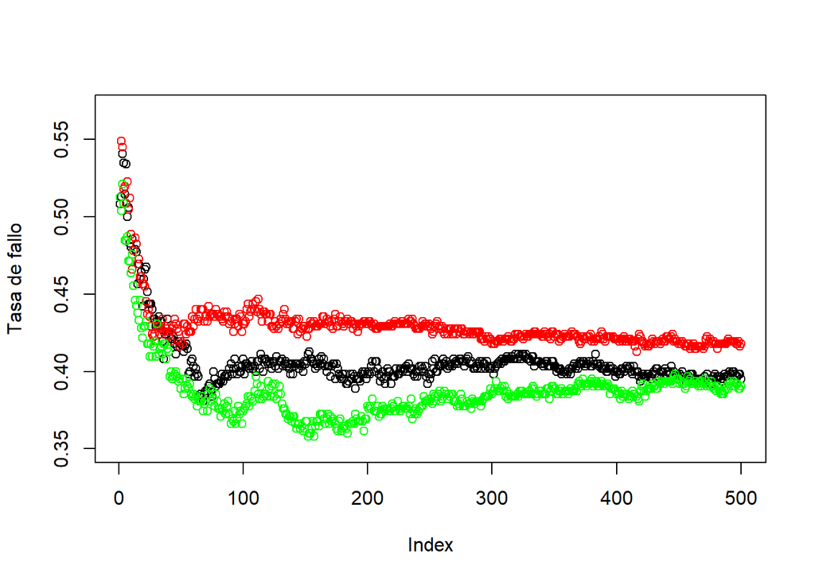

```r
set.seed(12345)
RF1<-randomForest(Sleep_Quality~., data=data_clasif_train,
                                          keep.inbag = TRUE,
                                          nodesize=ceiling(0.01*nrow(data_clasif_train)))
results1 <- OOBCurve(RF1, measures = list(kappa),
                    task = auxtask, data = data_clasif_train)
set.seed(12345)
RF05<-randomForest(Sleep_Quality~., data=data_clasif_train,
                                          keep.inbag = TRUE,
                                          nodesize=ceiling(0.005*nrow(data_clasif_train)))
results05 <- OOBCurve(RF05, measures = list(kappa),
                    task = auxtask, data = data_clasif_train)

plot(RF1$err.rate[,1], ylab = "Tasa de fallo", ylim=c(0.35,0.57))
points(RF5$err.rate[,1], col="red")
points(RF05$err.rate[,1], col="green")
```

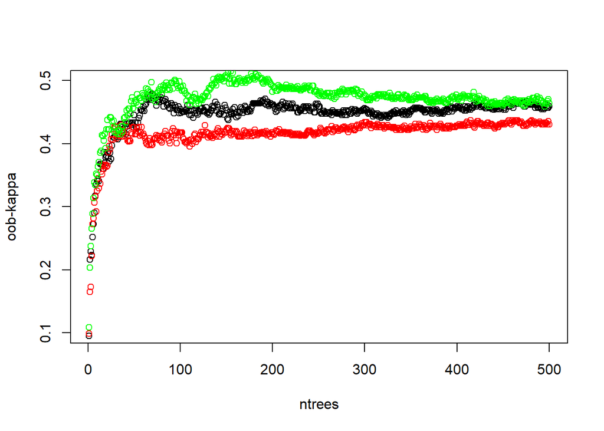

```r
plot(results1$kappa, ylab = "oob-kappa", xlab = "ntrees", ylim=c(0.1,0.5))
points(results_5$kappa, col="red")
points(results05$kappa, col="green")
```

Así mismo, el mejor valor se alcanza cuando el número de árboles está alrededor de 150.

El último parámetro que queda popr determinar es mtry (número de variables entre las que puede elegir para hacer cada una de las divisiones del árbol)

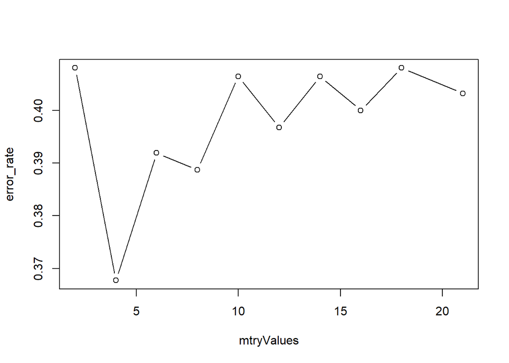

```r
future::plan(multisession, workers=detectCores() - 1)
mtryValues<-floor(seq(2,ncol(data_clasif_train)-1, length.out=10))

nt<-150
tunningRF<- future_map(mtryValues,
                         ~ {set.seed(12345);
                           randomForest(Sleep_Quality~., data=data_clasif_train,
                                        keep.inbag = TRUE,
                             nodesize=ceiling(0.005*nrow(data_clasif_train)),
                             ntree=nt,
                             mtry=.x)}
                         )
plan(sequential)

error_rate<-sapply(tunningRF, function(x) x$err.rate[nt,1])
plot(mtryValues,error_rate,type="b")
```

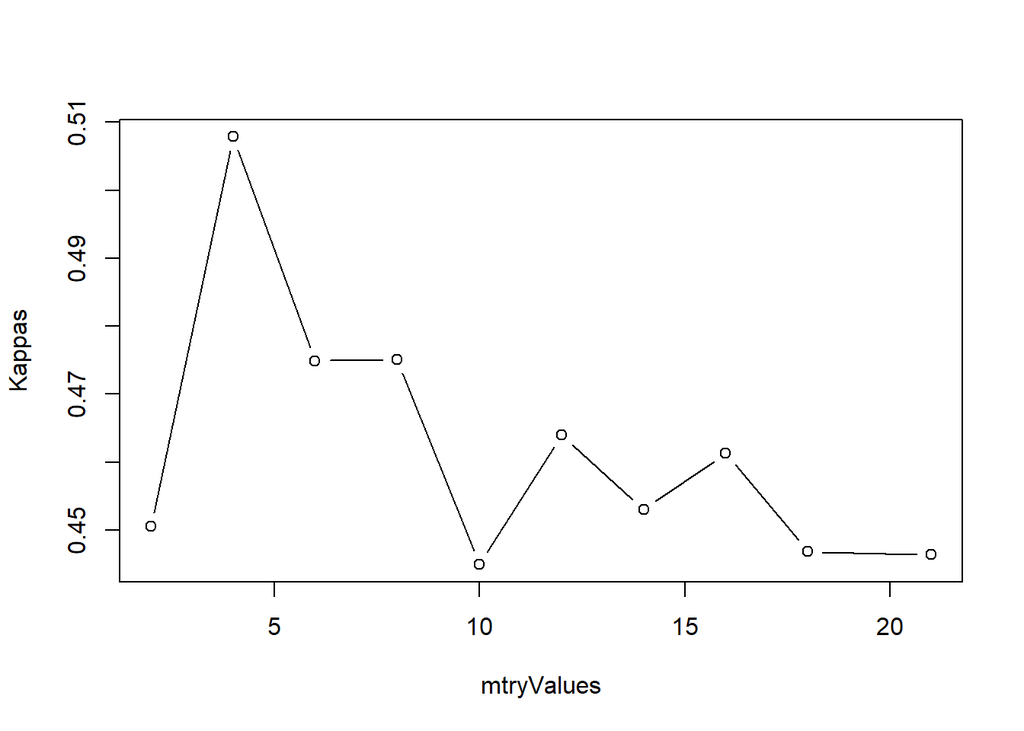

```r
Kappas<-sapply(tunningRF, function(x) OOBCurve(x, measures = list(kappa),
                         task = auxtask, data = data_clasif_train)$kappa[nt])
plot(mtryValues, Kappas, type="b")
```

Como podemos observar, ambos indicadores coninciden en el valor óptimo de mtry de 4. Además, se comprueba que esta fuente de aleatoriedad permite resultados mejores respecto al bagging (que sería utilizando las 21 variables predictoras restantes).

## Modelo Ganador

```r
RFdef<-tunningRF[[which(mtryValues==4)]]
print(RFdef)
```

```
Call:
 randomForest(formula = Sleep_Quality ~ ., data = data_clasif_train,      keep.inbag = TRUE, nodesize = ceiling(0.005 * nrow(data_clasif_train)),      ntree = nt, mtry = .x)
               Type of random forest: classification
                     Number of trees: 150
No. of variables tried at each split: 4

        OOB estimate of  error rate: 36.77%
Confusion matrix:
   1   2   3  4 class.error
1 97  12  23  0   0.2651515
2 16 103  22  4   0.2896552
3 16  41 126 28   0.4028436
4  1   9  56 66   0.5000000
```

Se observa que efectivameente la tasa de error ha disminuido de casi un 42% a un 37%, clasifica por lo general mejor las clases aunque en la que más falla es en la última Excelente, donde la mitad de los casos los clasifica bien y la otra mitad no.

```r
multiclass.roc(data_clasif_train$Sleep_Quality,
    predict(RFdef,data_clasif_train,type="prob"))$auc
```

```
Multi-class area under the curve: 0.9981
```

## Importancia de Variables

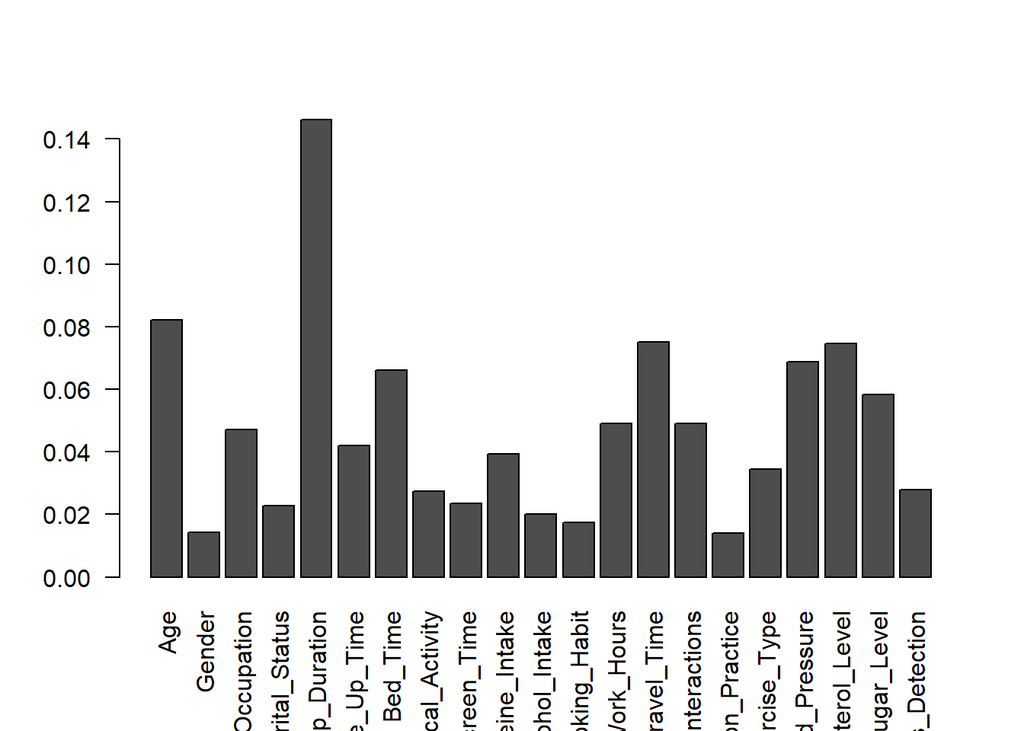

```r
barplot(t(RFdef$importance)/sum(RFdef$importance), las=2)
```

Respecto a la importancia de variables se observa que la más importante sigue siendo Sleep_Duration, el resto de variables, aunque importantes, están muy repartidas en porcentaje entre ellas.

Esto sucede porque la aleatoriedad añadida con mtry en los RF permite que se aproveche más el potencial predictivo de las variables “no dominantes” o menos importantes en modelos anteriores.

## Evaluación del Modelo

Finalmente, obtenemos una estimación de calidad en la partición de prueba

```r
multiclass.roc(data_clasif_test$Sleep_Quality,
    predict(RFdef,data_clasif_test,type="prob"))$auc
```

```
Multi-class area under the curve: 0.8658
```

```r
cm_test<-confusionMatrix(table((predict(RFdef, newdata=data_clasif_test)),data_clasif_test$Sleep_Quality))

cm_test$table
```

```
     1  2  3  4
  1 23  1  5  0
  2  3 28 11  4
  3  5  6 30 13
  4  1  1  6 16
```

```r
cm_test$overall[1]
```

```
 Accuracy
0.6339869
```

```r
Kappa(cm_test$table)
```

```
            value     ASE      z  Pr(>|z|)
Unweighted 0.5026 0.05351  9.393 5.843e-21
Weighted   0.5752 0.05209 11.042 2.389e-28
```

```r
cm_test$byClass[,1:2]
```

```
         Sensitivity Specificity
Class: 1   0.7187500   0.9504132
Class: 2   0.7777778   0.8461538
Class: 3   0.5769231   0.7623762
Class: 4   0.4848485   0.9333333
```

Como podemos obsevar, se ha creado un modelo con una calidad decente, el AUC estimado es de 0.87, un índice Kappa de 0.5 y tasa de acierto de 63.

Respecto a la sensibilidad y especificidad observamos que todas las categorías cuentan con una especificidad mayor que sensibilidad, es decir, son mejores indicando que observación no pertenece a su categoría que indicar cuales si pero, las categorías Pobre y Aceptable cuentan con una sensibilidad superior a 0.7, que no está mal, Buena llega a 0.57 y Excelente tiene una sensibilidad ligeramente inferior a 0.5. Como veníamos indicando, es la categoría a la que más le cuesta asociar observaciones

## Gráficos de Variables

Aún así, vamos a graficar como las distintas variables importantes influyen a cada categoría

Partiendo de la variable más importate, Sleep_Duration

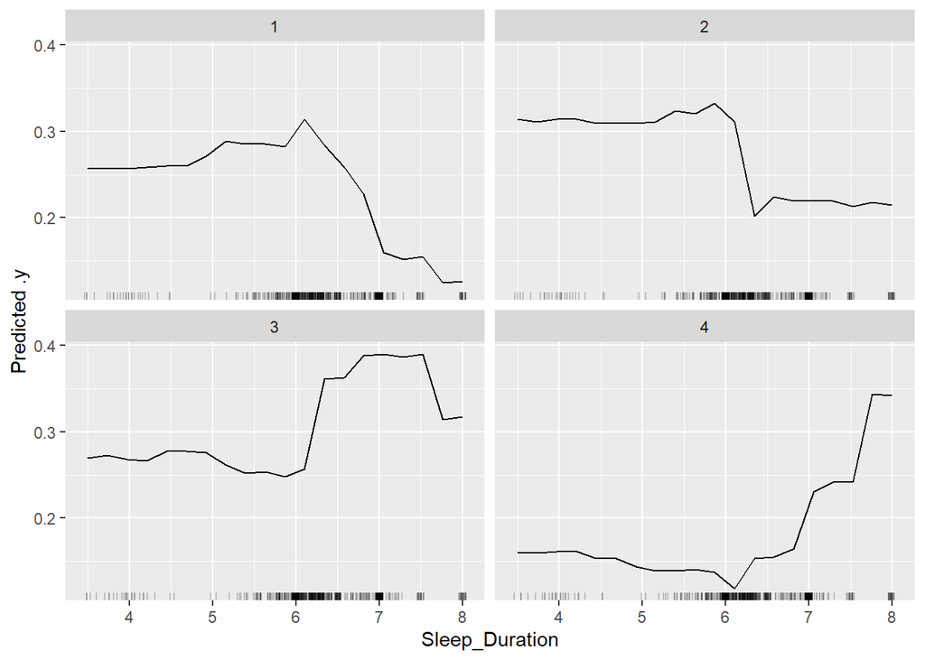

```r
predictor <- Predictor$new(RFdef, data = data_clasif_train, y = data_clasif_train$Sleep_Quality)
pdp <- FeatureEffect$new(predictor, feature = "Sleep_Duration", method="pdp")
pdp$plot()
```

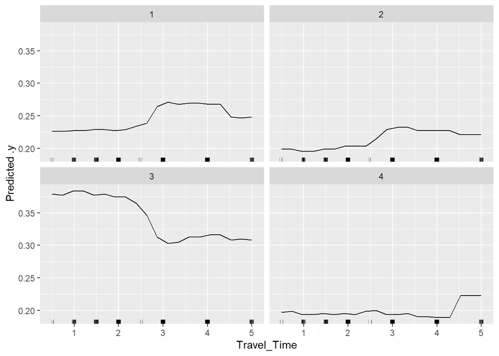

```r
predictor <- Predictor$new(RFdef, data = data_clasif_train, y = data_clasif_train$Sleep_Quality)
pdp <- FeatureEffect$new(predictor, feature = "Travel_Time", method="pdp")
pdp$plot()
```

Se observa claramente como aquellos que califican su percepción de calidad de sueño como Buena o Excelente duermen entre 6 y 8 horas mientras que aquellos que sienten que han tenido una calidad de sueño Pobre o Aceptable se encuentran mayoritariamente entre las 4 y 6 horas de sueño.

# Modelo Gradient Boosting

Finalmente el último tipo de modelo que vamos a realizar es Gradient Boosting. Sigue más o menos la temática de los Random Forest pero, en vez de crear un montón de árboles distintos entre ellos, van de manera secuencial capturando nueva información. Esto logra una aproximación iterativa al optimo de una determinada función, la cual permite evaliar la capacidad predicitiva del conjunto

## Modelo Inicial

Para poder realizar este tipo de modelos, es necesario que la variable objetivo esté codificada como 0, 1, 2 y 3 y, además, ser de tipo numérico, por lo que hay que hacer dicha modificación previa y luego se realiza la partición

```r
datos$Sleep_Quality<-as.numeric(datos$Sleep_Quality)-1

set.seed(12345)
trainIndex <- createDataPartition(datos$Sleep_Quality, p=0.8, list=FALSE)
data_clasif_train <- datos[trainIndex,]
data_clasif_test <- datos[-trainIndex,]
```

De manera análoga a los modelos anteriores, comenzamos creando un GB genérico.

Como utilizamos una variable que toma más de dos niveles, en la distribución de los datos indicamos “multinomial” en vez de “bernoulli”.

Vamos a realizar 5000 árboles con una tasa de aprendizaje de 0.1, tamaño mínimo de hoja del 5%, utilizando el 75% de los datos como entrenamiento y el 25% restante para validación y una profundidad del árbol 3

```r
set.seed(12345)
data_clasif_train_reord <- data_clasif_train[sample(nrow(data_clasif_train)),]

set.seed(12345)
gbm_clasif_5 <- gbm(
  formula = Sleep_Quality~., data=data_clasif_train_reord,
  distribution = "multinomial",
  train.fraction = 0.75,
  n.trees = 5000,
  shrinkage = 0.1,
  bag.fraction = 1,
  interaction.depth = 3,
  n.minobsinnode = ceiling(0.05*nrow(data_clasif_train_reord))
)
print(gbm_clasif_5)
```

```
gbm(formula = Sleep_Quality ~ ., distribution = "multinomial",
    data = data_clasif_train_reord, n.trees = 5000, interaction.depth = 3,
    n.minobsinnode = ceiling(0.05 * nrow(data_clasif_train_reord)),
    shrinkage = 0.1, bag.fraction = 1, train.fraction = 0.75)
A gradient boosted model with multinomial loss function.
5000 iterations were performed.
The best test-set iteration was 69.
There were 21 predictors of which 21 had non-zero influence.
```

Como podemos observar, se ha construido un GBM para clasificación con 5000 árboles, donde la partición de validación ha indicado que serían sólo necesarios los 69 primeros y se han utilizado todas las variables.

Vamos a representar gráficamente la evolución de la deviance tanto en entrenamiento (negro) como en validación (rojo)

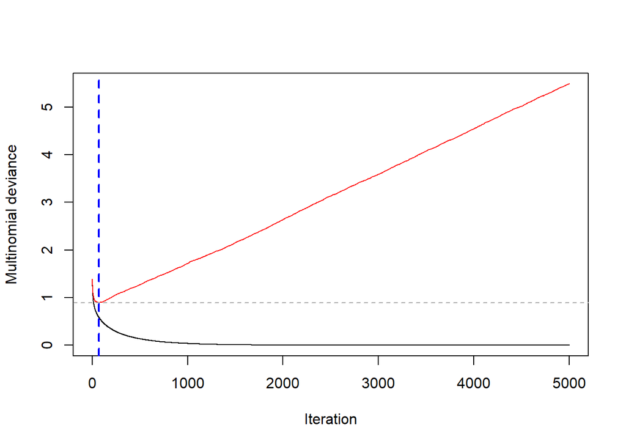

```r
opt_clasif_gbm5<-gbm.perf(gbm_clasif_5)
abline(h=gbm_clasif_5$valid.error[opt_clasif_gbm5], lty=2, col="darkgray")
```

La línea vertical indica donde se ubica el valor óptimo.

Se aprecia claramente como pasada dicha línea, se obtienen peores resultados y cada vez hay mayor sobreajuste.

## Rejilla de Parámetros

A continuación, vamos a construir una rejilla de parámetros a evaluar para poder compararlos. Vamos a limitar las opciones de cada parámetro a 4 para no alargar mucho los procesos pero podemos y deberíamos ampliar este número

```r
hyper_grid <- expand.grid(
  shrinkage = c(0.1, 0.05, 0.01, 0.005),
  interaction.depth = c(3, 5, 7, 9),
  n.minobsinnode = c(ceiling(0.01*nrow(data_clasif_train_reord)), ceiling(0.05*nrow(data_clasif_train_reord)),
           ceiling(0.02*nrow(data_clasif_train_reord)), ceiling(0.005*nrow(data_clasif_train_reord)))
)
```

Creada la rejilla, creamos un modelo para cada una de las 64 combinaciones

```r
future::plan(multisession, workers=detectCores() - 1)

set.seed(12345)
tunningGB<- future_map(1:nrow(hyper_grid),
                         ~ {set.seed(12345);
                           gbm(formula = Sleep_Quality~., data=data_clasif_train_reord,
                               distribution = "multinomial",
                               n.trees = 5000,
                               train.fraction = 0.75,
                               shrinkage = hyper_grid$shrinkage[.x],
                               bag.fraction = 1,
                               interaction.depth = hyper_grid$interaction.depth[.x],
                               n.minobsinnode = hyper_grid$n.minobsinnode[.x]
                         )}
                       )
plan(sequential)
```

A continuación, lo representamos gráficamente

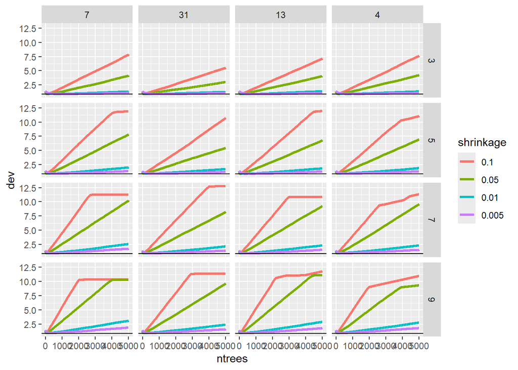

```r
resultado <- map_df(1:nrow(hyper_grid),
                    function(x) {
                      data.frame(
                        shrinkage = as.factor(hyper_grid$shrinkage[x]),
                        interaction.depth = as.factor(hyper_grid$interaction.depth[x]),
                        n.minobsinnode = as.factor(hyper_grid$n.minobsinnode[x]),
                        ntrees = 1:5000,
                        dev = tunningGB[[x]]$valid.error
                      )

                    }

)

ggplot(data=resultado, aes(x=ntrees, y=dev, col=shrinkage))+
  geom_line(lwd=1.1)+
  geom_hline(yintercept = min(resultado$dev))+
  facet_grid(interaction.depth ~ n.minobsinnode)
```

```r
resultado %>%
     group_by(interaction.depth, n.minobsinnode, shrinkage) %>%
     slice_min(dev, n = 1)%>%
     arrange(dev)
```

```
# A tibble: 64 × 5
# Groups:   interaction.depth, n.minobsinnode, shrinkage [64]
   shrinkage interaction.depth n.minobsinnode ntrees   dev
   <fct>     <fct>             <fct>           <int> <dbl>
 1 0.05      3                 13                125 0.885
 2 0.005     3                 13               1271 0.885
 3 0.01      3                 13                640 0.887
 4 0.05      3                 31                138 0.888
 5 0.01      3                 31                652 0.889
 6 0.1       3                 31                 69 0.890
 7 0.005     3                 31               1263 0.890
 8 0.1       3                 13                 64 0.893
 9 0.01      3                 7                 676 0.901
10 0.005     3                 7                1347 0.902
# ℹ 54 more rows
```

En la representación vemos como cada uno de los parámetros impacta en el GBM.

```r
optComb<-which((hyper_grid$shrinkage==0.05)&(hyper_grid$interaction.depth==3)&(hyper_grid$n.minobsinnode==31))
print(tunningGB[[optComb]])
```

```
gbm(formula = Sleep_Quality ~ ., distribution = "multinomial",
    data = data_clasif_train_reord, n.trees = 5000, interaction.depth = hyper_grid$interaction.depth[.x],
    n.minobsinnode = hyper_grid$n.minobsinnode[.x], shrinkage = hyper_grid$shrinkage[.x],
    bag.fraction = 1, train.fraction = 0.75)
A gradient boosted model with multinomial loss function.
5000 iterations were performed.
The best test-set iteration was 138.
There were 21 predictors of which 21 had non-zero influence.
```

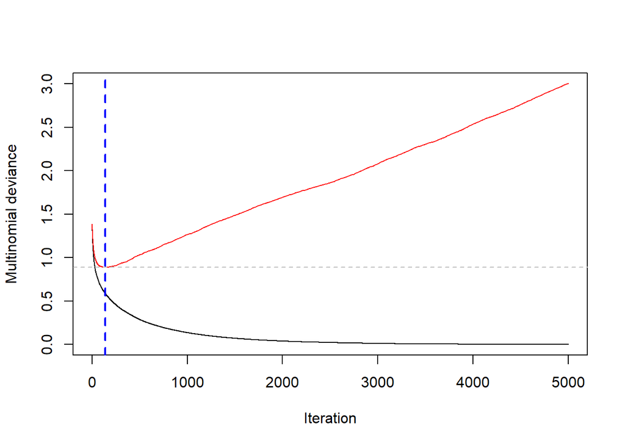

```r
opt_gbm<-gbm.perf(tunningGB[[optComb]])
abline(h=tunningGB[[optComb]]$valid.error[opt_gbm], lty=2, col="gray")
```

Parece que con 138 o incluso 100 para redondear vamos a obtener mñas o menos los mismos resultados y no hay ninguna otra solución que permita reducir significativamente el sobreajuste

## Modelo Ganador

Una vez descubierta la parametrización óptima, construimos el modelo final utilizando los datos de entrenamiento al completo para mejorar la capacidad predictiva y más adelante determinar su calidad final

```r
set.seed(12345)
gbm_clasif_opt<- gbm(
  formula = Sleep_Quality~., data=data_clasif_train,
  distribution = "multinomial",
  train.fraction = 1,
  n.trees = 130,
  shrinkage = 0.05,
  bag.fraction = 1,
  interaction.depth = 3,
  n.minobsinnode = 31
)
print(gbm_clasif_opt)
```

```
gbm(formula = Sleep_Quality ~ ., distribution = "multinomial",
    data = data_clasif_train, n.trees = 130, interaction.depth = 3,
    n.minobsinnode = 31, shrinkage = 0.05, bag.fraction = 1,
    train.fraction = 1)
A gradient boosted model with multinomial loss function.
130 iterations were performed.
There were 21 predictors of which 21 had non-zero influence.
```

## Evaluación del Modelo

Obtenemos tanto los valores de AUC como la matriz de confusión

```r
pred_array <- predict(
  gbm_clasif_opt,
  data_clasif_train,
  n.trees = gbm_clasif_opt$n.trees, # Asegura usar el número de árboles entrenados (130)
  type = "response"
)

# 2. Extracción de la matriz 2D de probabilidades (Dimensiones: 619 x 4)
# Seleccionamos la única "capa" (índice 1) de la tercera dimensión
pred_matrix <- pred_array[,,1]

# 3. Calcular el AUC Multiclase
AUC_multiclase <- pROC::multiclass.roc(data_clasif_train$Sleep_Quality, pred_matrix)$auc

# 4. Imprimir el resultado
print(AUC_multiclase)
```

```
Multi-class area under the curve: 0.9417
```

```r
pred_array <- predict(
  gbm_clasif_opt,
  data_clasif_test,
  n.trees = gbm_clasif_opt$n.trees, # Asegura usar el número de árboles entrenados (130)
  type = "response"
)

# 2. Extracción de la matriz 2D de probabilidades (Dimensiones: 619 x 4)
# Seleccionamos la única "capa" (índice 1) de la tercera dimensión
pred_matrix <- pred_array[,,1]

# 3. Calcular el AUC Multiclase
AUC_multiclase <- pROC::multiclass.roc(data_clasif_test$Sleep_Quality, pred_matrix)$auc

# 4. Imprimir el resultado
print(AUC_multiclase)
```

```
Multi-class area under the curve: 0.8408
```

Accuracy, kappa y sensibilidades y especificidades.

```r
n_trees_optimo <- gbm_clasif_opt$n.trees

pred_array_test <- predict(
    gbm_clasif_opt,
    newdata = data_test,
    n.trees = n_trees_optimo,
    type = "response"
)

pred_matrix_test <- pred_array_test[,,1]

niveles_clase <- levels(data_test$Sleep_Quality)
if (is.null(niveles_clase)) {
    niveles_clase <- sort(unique(data_test$Sleep_Quality))
}

colnames(pred_matrix_test) <- niveles_clase
pred_clases_test <- colnames(pred_matrix_test)[apply(pred_matrix_test, 1, which.max)]
pred_clases_test <- factor(pred_clases_test, levels = niveles_clase)

cm_test <- confusionMatrix(
    data = pred_clases_test,          # Clases predichas (Factor)
    reference = data_test$Sleep_Quality # Clases reales (Factor)
)

cm_test$table
```

```
           Reference
Prediction  Pobre Aceptable Buena Excelente
  Pobre        23         2     5         1
  Aceptable     2        29     5         2
  Buena         5         5    37        10
  Excelente     2         0     5        20
```

```r
cm_test$overall[c("Accuracy", "Kappa")]
```

```
 Accuracy     Kappa
0.7124183 0.6084681
```

```r
Kappa(cm_test$table)
```

```
            value     ASE     z  Pr(>|z|)
Unweighted 0.6085 0.05020 12.12 8.081e-34
Weighted   0.6438 0.05136 12.54 4.799e-36
```

```r
cm_test$byClass[, c("Sensitivity", "Specificity")]
```

```
                 Sensitivity Specificity
Class: Pobre       0.7187500   0.9338843
Class: Aceptable   0.8055556   0.9230769
Class: Buena       0.7115385   0.8019802
Class: Excelente   0.6060606   0.9416667
```

çY para train

```r
pred_array <- predict(
  gbm_clasif_opt,
  data_clasif_train,
  n.trees = gbm_clasif_opt$n.trees,
  type = "response"
)
pred_matrix <- pred_array[,,1]
niveles_clase_ref <- levels(data_clasif_train$Sleep_Quality)

if (is.null(niveles_clase_ref)) {
    niveles_clase_ref <- sort(unique(data_clasif_train$Sleep_Quality))
    data_clasif_train$Sleep_Quality <- factor(data_clasif_train$Sleep_Quality,
                                              levels = niveles_clase_ref)
}

colnames(pred_matrix) <- niveles_clase_ref
pred_clases_train_raw <- colnames(pred_matrix)[apply(pred_matrix, 1, which.max)]
pred_clases_train <- factor(pred_clases_train_raw, levels = niveles_clase_ref)

cm_train <- confusionMatrix(
    data = pred_clases_train,
    reference = data_clasif_train$Sleep_Quality
)

cm_train$table
```

```
          Reference
Prediction   0   1   2   3
         0 111   9  10   0
         1   8 109  22   8
         2  17  18 159  34
         3   2   2  20  90
```

```r
cm_train$overall[c("Accuracy", "Kappa")]
```

```
 Accuracy     Kappa
0.7576737 0.6704864
```

```r
cm_train$byClass[, c("Sensitivity", "Specificity")]
```

```
         Sensitivity Specificity
Class: 0   0.8043478   0.9604990
Class: 1   0.7898551   0.9209979
Class: 2   0.7535545   0.8308824
Class: 3   0.6818182   0.9507187
```

## Importancia de las Variables

Finalemnte, observamos la importancia de las variables

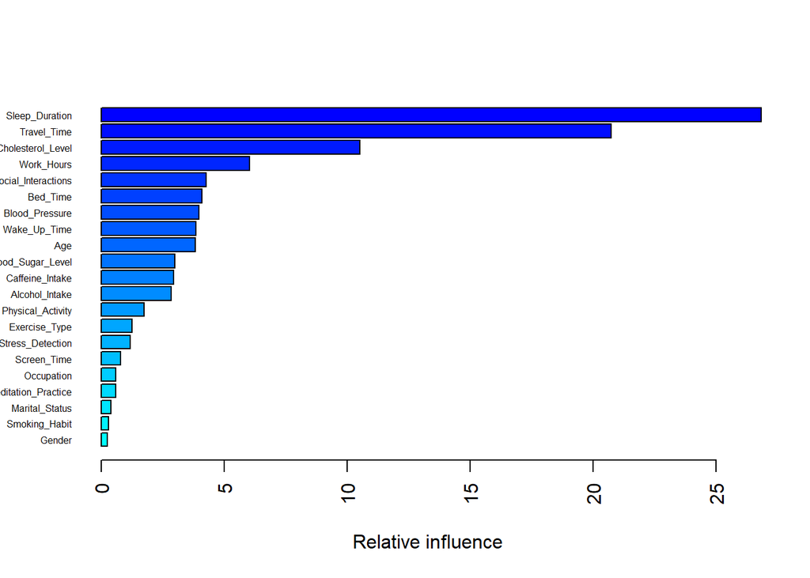

```
                                    var    rel.inf
Sleep_Duration           Sleep_Duration 26.8293713
Travel_Time                 Travel_Time 20.7319431
Cholesterol_Level     Cholesterol_Level 10.5056008
Work_Hours                   Work_Hours  6.0417555
Social_Interactions Social_Interactions  4.2673385
Bed_Time                       Bed_Time  4.1042407
Blood_Pressure           Blood_Pressure  3.9788158
Wake_Up_Time               Wake_Up_Time  3.8465322
Age                                 Age  3.8336118
Blood_Sugar_Level     Blood_Sugar_Level  2.9821662
Caffeine_Intake         Caffeine_Intake  2.9355375
Alcohol_Intake           Alcohol_Intake  2.8540974
Physical_Activity     Physical_Activity  1.7370493
Exercise_Type             Exercise_Type  1.2634732
Stress_Detection       Stress_Detection  1.1670641
Screen_Time                 Screen_Time  0.7916989
Occupation                   Occupation  0.5984244
Meditation_Practice Meditation_Practice  0.5802062
Marital_Status           Marital_Status  0.4016970
Smoking_Habit             Smoking_Habit  0.2966212
Gender                           Gender  0.2527551
```

```r
summary(gbm_clasif_opt, las=2, cex.names=.5)
```